# Capstone

```python
import numpy as np
import pandas as pd
import os

import matplotlib.pylab as plt
import seaborn as sns
import plotly.express as px
import plotly.graph_objects as go
from plotly.subplots import make_subplots
%matplotlib inline
```

```python
for dirname, _, filenames in os.walk('/kaggle/input'):
    for filename in filenames:
        print(os.path.join(dirname, filename))
```

```python
from google.colab import drive
drive.mount('/content/drive', force_remount=True)
```

```python
file_path = '/content/drive/My Drive/datascience/zomato.csv'
```

```python
# Load the dataset
df = pd.read_csv(file_path)

# Display the first few rows of the dataframe
df.head()
```

|  | url | address | name | online_order | book_table | rate | votes | phone | location | rest_type | dish_liked | cuisines | approx_cost(for two people) | reviews_list | menu_item | listed_in(type) | listed_in(city) |
| --- | --- | --- | --- | --- | --- | --- | --- | --- | --- | --- | --- | --- | --- | --- | --- | --- | --- |
| 0 | https://www.zomato.com/bangalore/jalsa-banasha... | 942, 21st Main Road, 2nd Stage, Banashankari, ... | Jalsa | Yes | Yes | 4.1/5 | 775 | 080 42297555\r\n+91 9743772233 | Banashankari | Casual Dining | Pasta, Lunch Buffet, Masala Papad, Paneer Laja... | North Indian, Mughlai, Chinese | 800 | [('Rated 4.0', 'RATED\n A beautiful place to ... | [] | Buffet | Banashankari |
| 1 | https://www.zomato.com/bangalore/spice-elephan... | 2nd Floor, 80 Feet Road, Near Big Bazaar, 6th ... | Spice Elephant | Yes | No | 4.1/5 | 787 | 080 41714161 | Banashankari | Casual Dining | Momos, Lunch Buffet, Chocolate Nirvana, Thai G... | Chinese, North Indian, Thai | 800 | [('Rated 4.0', 'RATED\n Had been here for din... | [] | Buffet | Banashankari |
| 2 | https://www.zomato.com/SanchurroBangalore?cont... | 1112, Next to KIMS Medical College, 17th Cross... | San Churro Cafe | Yes | No | 3.8/5 | 918 | +91 9663487993 | Banashankari | Cafe, Casual Dining | Churros, Cannelloni, Minestrone Soup, Hot Choc... | Cafe, Mexican, Italian | 800 | [('Rated 3.0', "RATED\n Ambience is not that ... | [] | Buffet | Banashankari |
| 3 | https://www.zomato.com/bangalore/addhuri-udupi... | 1st Floor, Annakuteera, 3rd Stage, Banashankar... | Addhuri Udupi Bhojana | No | No | 3.7/5 | 88 | +91 9620009302 | Banashankari | Quick Bites | Masala Dosa | South Indian, North Indian | 300 | [('Rated 4.0', "RATED\n Great food and proper... | [] | Buffet | Banashankari |
| 4 | https://www.zomato.com/bangalore/grand-village... | 10, 3rd Floor, Lakshmi Associates, Gandhi Baza... | Grand Village | No | No | 3.8/5 | 166 | +91 8026612447\r\n+91 9901210005 | Basavanagudi | Casual Dining | Panipuri, Gol Gappe | North Indian, Rajasthani | 600 | [('Rated 4.0', 'RATED\n Very good restaurant ... | [] | Buffet | Banashankari |

```python
df.shape
```

```
(51717, 17)
```

```python
df.info()
```

```
<class 'pandas.core.frame.DataFrame'>
RangeIndex: 51717 entries, 0 to 51716
Data columns (total 17 columns):
 #   Column                       Non-Null Count  Dtype
---  ------                       --------------  -----
 0   url                          51717 non-null  object
 1   address                      51717 non-null  object
 2   name                         51717 non-null  object
 3   online_order                 51717 non-null  object
 4   book_table                   51717 non-null  object
 5   rate                         43942 non-null  object
 6   votes                        51717 non-null  int64
 7   phone                        50509 non-null  object
 8   location                     51696 non-null  object
 9   rest_type                    51490 non-null  object
 10  dish_liked                   23639 non-null  object
 11  cuisines                     51672 non-null  object
 12  approx_cost(for two people)  51371 non-null  object
 13  reviews_list                 51717 non-null  object
 14  menu_item                    51717 non-null  object
 15  listed_in(type)              51717 non-null  object
 16  listed_in(city)              51717 non-null  object
dtypes: int64(1), object(16)
memory usage: 6.7+ MB
```

```python
categorical=df.select_dtypes(include="object").columns
categorical
```

```
Index(['url', 'address', 'name', 'online_order', 'book_table', 'rate', 'phone',
       'location', 'rest_type', 'dish_liked', 'cuisines',
       'approx_cost(for two people)', 'reviews_list', 'menu_item',
       'listed_in(type)', 'listed_in(city)'],
      dtype='object')
```

```python
len(df.address.unique())
```

```
11495
```

```python
len(df.url.unique())
```

```
51717
```

```python
len(df.phone.unique())
```

```
14927
```

```python
df["phone"].value_counts()
```

```
phone
080 43334321                          216
080 43334333                          167
+91 7005889963                         78
+91 8197170008                         75
+91 7710055553                         58
                                     ...
+91 9845687999\r\r\n080 41494199        1
+91 9606443393\r\r\n+91 9606443394      1
+91 9538798222                          1
080 48902064\r\r\n+91 9620723546        1
+91 8884297989\r\r\n+91 9886759367      1
Name: count, Length: 14926, dtype: int64
```

convert all restaurtant that have phone number to "have phone",and convert all restaurtant that donot have phone number to "not have phone". Similarly for Menu_item

# **Feature engineering**

**MENU_ITEM**

```python
def convert(x):
    if x=="[]":
        return "not have menu"
    else:
        return "have menu"
```

```python
df.head()
```

|  | url | address | name | online_order | book_table | rate | votes | phone | location | rest_type | dish_liked | cuisines | approx_cost(for two people) | reviews_list | menu_item | listed_in(type) | listed_in(city) |
| --- | --- | --- | --- | --- | --- | --- | --- | --- | --- | --- | --- | --- | --- | --- | --- | --- | --- |
| 0 | https://www.zomato.com/bangalore/jalsa-banasha... | 942, 21st Main Road, 2nd Stage, Banashankari, ... | Jalsa | Yes | Yes | 4.1/5 | 775 | 080 42297555\r\n+91 9743772233 | Banashankari | Casual Dining | Pasta, Lunch Buffet, Masala Papad, Paneer Laja... | North Indian, Mughlai, Chinese | 800 | [('Rated 4.0', 'RATED\n A beautiful place to ... | [] | Buffet | Banashankari |
| 1 | https://www.zomato.com/bangalore/spice-elephan... | 2nd Floor, 80 Feet Road, Near Big Bazaar, 6th ... | Spice Elephant | Yes | No | 4.1/5 | 787 | 080 41714161 | Banashankari | Casual Dining | Momos, Lunch Buffet, Chocolate Nirvana, Thai G... | Chinese, North Indian, Thai | 800 | [('Rated 4.0', 'RATED\n Had been here for din... | [] | Buffet | Banashankari |
| 2 | https://www.zomato.com/SanchurroBangalore?cont... | 1112, Next to KIMS Medical College, 17th Cross... | San Churro Cafe | Yes | No | 3.8/5 | 918 | +91 9663487993 | Banashankari | Cafe, Casual Dining | Churros, Cannelloni, Minestrone Soup, Hot Choc... | Cafe, Mexican, Italian | 800 | [('Rated 3.0', "RATED\n Ambience is not that ... | [] | Buffet | Banashankari |
| 3 | https://www.zomato.com/bangalore/addhuri-udupi... | 1st Floor, Annakuteera, 3rd Stage, Banashankar... | Addhuri Udupi Bhojana | No | No | 3.7/5 | 88 | +91 9620009302 | Banashankari | Quick Bites | Masala Dosa | South Indian, North Indian | 300 | [('Rated 4.0', "RATED\n Great food and proper... | [] | Buffet | Banashankari |
| 4 | https://www.zomato.com/bangalore/grand-village... | 10, 3rd Floor, Lakshmi Associates, Gandhi Baza... | Grand Village | No | No | 3.8/5 | 166 | +91 8026612447\r\n+91 9901210005 | Basavanagudi | Casual Dining | Panipuri, Gol Gappe | North Indian, Rajasthani | 600 | [('Rated 4.0', 'RATED\n Very good restaurant ... | [] | Buffet | Banashankari |

```python
df['menu_item_c'] = df['menu_item'].apply(convert)
```

```python
df.head()
```

|  | url | address | name | online_order | book_table | rate | votes | phone | location | rest_type | dish_liked | cuisines | approx_cost(for two people) | reviews_list | menu_item | listed_in(type) | listed_in(city) | menu_item_c |
| --- | --- | --- | --- | --- | --- | --- | --- | --- | --- | --- | --- | --- | --- | --- | --- | --- | --- | --- |
| 0 | https://www.zomato.com/bangalore/jalsa-banasha... | 942, 21st Main Road, 2nd Stage, Banashankari, ... | Jalsa | Yes | Yes | 4.1/5 | 775 | 080 42297555\r\n+91 9743772233 | Banashankari | Casual Dining | Pasta, Lunch Buffet, Masala Papad, Paneer Laja... | North Indian, Mughlai, Chinese | 800 | [('Rated 4.0', 'RATED\n A beautiful place to ... | [] | Buffet | Banashankari | not have menu |
| 1 | https://www.zomato.com/bangalore/spice-elephan... | 2nd Floor, 80 Feet Road, Near Big Bazaar, 6th ... | Spice Elephant | Yes | No | 4.1/5 | 787 | 080 41714161 | Banashankari | Casual Dining | Momos, Lunch Buffet, Chocolate Nirvana, Thai G... | Chinese, North Indian, Thai | 800 | [('Rated 4.0', 'RATED\n Had been here for din... | [] | Buffet | Banashankari | not have menu |
| 2 | https://www.zomato.com/SanchurroBangalore?cont... | 1112, Next to KIMS Medical College, 17th Cross... | San Churro Cafe | Yes | No | 3.8/5 | 918 | +91 9663487993 | Banashankari | Cafe, Casual Dining | Churros, Cannelloni, Minestrone Soup, Hot Choc... | Cafe, Mexican, Italian | 800 | [('Rated 3.0', "RATED\n Ambience is not that ... | [] | Buffet | Banashankari | not have menu |
| 3 | https://www.zomato.com/bangalore/addhuri-udupi... | 1st Floor, Annakuteera, 3rd Stage, Banashankar... | Addhuri Udupi Bhojana | No | No | 3.7/5 | 88 | +91 9620009302 | Banashankari | Quick Bites | Masala Dosa | South Indian, North Indian | 300 | [('Rated 4.0', "RATED\n Great food and proper... | [] | Buffet | Banashankari | not have menu |
| 4 | https://www.zomato.com/bangalore/grand-village... | 10, 3rd Floor, Lakshmi Associates, Gandhi Baza... | Grand Village | No | No | 3.8/5 | 166 | +91 8026612447\r\n+91 9901210005 | Basavanagudi | Casual Dining | Panipuri, Gol Gappe | North Indian, Rajasthani | 600 | [('Rated 4.0', 'RATED\n Very good restaurant ... | [] | Buffet | Banashankari | not have menu |

```python
df.sample(4)
```

|  | url | address | name | online_order | book_table | rate | votes | phone | location | rest_type | dish_liked | cuisines | approx_cost(for two people) | reviews_list | menu_item | listed_in(type) | listed_in(city) | menu_item_c |
| --- | --- | --- | --- | --- | --- | --- | --- | --- | --- | --- | --- | --- | --- | --- | --- | --- | --- | --- |
| 27610 | https://www.zomato.com/bangalore/the-smoke-co-... | 501, 6th Cross, Koramangala 6th Block, Bangalore | The Smoke Co. | Yes | Yes | 4.3/5 | 519 | +91 8046218500\r\n+91 8296394454 | Koramangala 6th Block | Casual Dining | Mysore Pak, Cocktails, Burgers, Pork Ribs, Fis... | American, European | 2,500 | [('Rated 4.0', 'RATED\n After a long time A p... | [] | Delivery | Koramangala 4th Block | not have menu |
| 7113 | https://www.zomato.com/bangalore/rajdhani-thal... | 3rd Floor, Forum Neighbourhood Mall, Varthur M... | Rajdhani Thali Restaurant | Yes | Yes | 3.8/5 | 741 | 080 25939309 | Whitefield | Casual Dining | Veg Thali, Aamras, Samosa, Buttermilk, Dal Bat... | North Indian | 900 | [('Rated 4.0', 'RATED\n This places is one of... | [] | Delivery | Brookefield | not have menu |
| 43191 | https://www.zomato.com/bangalore/cafe-mozaic-t... | Vivanta By Taj, 41/3, MG Road, Bangalore | Cafe Mozaic - Taj MG Road Bengaluru | No | Yes | 4.1 /5 | 568 | 080 66604266\n080 66604444 | MG Road | Casual Dining, Cafe | Paneer Lababdar, Sandwiches, Oysters, Paratha,... | North Indian, Italian, South Indian, Continent... | 2,500 | [('Rated 5.0', "RATED\n Taj Vivanta has alway... | [] | Dine-out | MG Road | not have menu |
| 4744 | https://www.zomato.com/bangalore/paratha-king-... | Third B cross, Bellandur Main Road, Bangalore | Paratha King | Yes | No | 3.1/5 | 19 | +91 9916824979 | Bellandur | Quick Bites | NaN | North Indian | 300 | [('Rated 1.0', 'RATED\n Bhen ke lodo..paratha... | [] | Dine-out | Bellandur | not have menu |

**PHONE**

```python
df.phone.isna().sum()
```

```
1208
```

```python
len(df.phone.unique())
```

```
14927
```

```python
df.phone=df.phone.fillna("not have phone")
def phone(x):
    if x=='not have phone':
        return x
    else:
        return "have phone"
```

```python
df.phone=df.phone.apply(phone)
```

```python
df.sample(4)
```

|  | url | address | name | online_order | book_table | rate | votes | phone | location | rest_type | dish_liked | cuisines | approx_cost(for two people) | reviews_list | menu_item | listed_in(type) | listed_in(city) | menu_item_c |
| --- | --- | --- | --- | --- | --- | --- | --- | --- | --- | --- | --- | --- | --- | --- | --- | --- | --- | --- |
| 4856 | https://www.zomato.com/bangalore/hyderabadi-bi... | 1, 6/2, Opposite Foodworld Supermarket, 12th C... | Hyderabadi Biryani Hub | Yes | No | 3.5/5 | 45 | have phone | Sarjapur Road | Quick Bites | NaN | Biryani, North Indian | 600 | [('Rated 4.0', 'RATED\n Tandoori chicken was ... | ['Tandoori Chicken Kebab', 'Tandoori Chicken',... | Dine-out | Bellandur | have menu |
| 6195 | https://www.zomato.com/bangalore/fort-kochi-mg... | Level 5, 1 MG Road Mall, Trinity Circle, MG Ro... | Fort Kochi | No | Yes | 4.1/5 | 335 | have phone | MG Road | Casual Dining, Bar | Sea Food, Appam, Fish, Kerala Parotta, Sangria... | Kerala, Seafood | 1,800 | [('Rated 4.0', 'RATED\n High end Malayali eat... | [] | Dine-out | Brigade Road | not have menu |
| 31229 | https://www.zomato.com/bangalore/sulaimani-cha... | 202, 17th 'E' Main, KHB Colony, Koramangala 5t... | Sulaimani Chai | No | No | 3.8 /5 | 21 | have phone | Koramangala 5th Block | Quick Bites | NaN | Fast Food, Beverages | 100 | [('Rated 5.0', 'RATED\n Chaigasm! Hands down ... | [] | Dine-out | Koramangala 5th Block | not have menu |
| 41963 | https://www.zomato.com/bangalore/happy-kitchen... | 4th A Cross, Shridi Sai Nagar, Munnekolla, Mar... | Happy Kitchen | No | No | 3.8 /5 | 78 | have phone | Marathahalli | Quick Bites | Biryani, Idli, Vada, Chicken Curry | North Indian, Chinese | 350 | [('Rated 1.0', "RATED\n Please don't order fo... | [] | Dine-out | Marathahalli | not have menu |

**RATE**

```python
df.rate
```

```
0         4.1/5
1         4.1/5
2         3.8/5
3         3.7/5
4         3.8/5
          ...
51712    3.6 /5
51713       NaN
51714       NaN
51715    4.3 /5
51716    3.4 /5
Name: rate, Length: 51717, dtype: object
```

```python
df.rate.str.split("/").str[0]
```

```
0         4.1
1         4.1
2         3.8
3         3.7
4         3.8
         ...
51712    3.6
51713     NaN
51714     NaN
51715    4.3
51716    3.4
Name: rate, Length: 51717, dtype: object
```

```python
df.rate=df.rate.str.split("/").str[0]
```

```python
df.rate.unique()
```

```
array(['4.1', '3.8', '3.7', '3.6', '4.6', '4.0', '4.2', '3.9', '3.1',
       '3.0', '3.2', '3.3', '2.8', '4.4', '4.3', 'NEW', '2.9', '3.5', nan,
       '2.6', '3.8 ', '3.4', '4.5', '2.5', '2.7', '4.7', '2.4', '2.2',
       '2.3', '3.4 ', '-', '3.6 ', '4.8', '3.9 ', '4.2 ', '4.0 ', '4.1 ',
       '3.7 ', '3.1 ', '2.9 ', '3.3 ', '2.8 ', '3.5 ', '2.7 ', '2.5 ',
       '3.2 ', '2.6 ', '4.5 ', '4.3 ', '4.4 ', '4.9', '2.1', '2.0', '1.8',
       '4.6 ', '4.9 ', '3.0 ', '4.8 ', '2.3 ', '4.7 ', '2.4 ', '2.1 ',
       '2.2 ', '2.0 ', '1.8 '], dtype=object)
```

```python
#convert data type
def rate(x):
    try:
        if x=="NEW":
            return 0
        else:
            return float(x)
    except:
        return np.nan
df.rate=df.rate.apply(rate)
```

```python
df.rate
```

```
0        4.1
1        4.1
2        3.8
3        3.7
4        3.8
        ...
51712    3.6
51713    NaN
51714    NaN
51715    4.3
51716    3.4
Name: rate, Length: 51717, dtype: float64
```

**approx_cost(for two people)**

```python
df["approx_cost(for two people)"].unique()
```

```
array(['800', '300', '600', '700', '550', '500', '450', '650', '400',
       '900', '200', '750', '150', '850', '100', '1,200', '350', '250',
       '950', '1,000', '1,500', '1,300', '199', '80', '1,100', '160',
       '1,600', '230', '130', '50', '190', '1,700', nan, '1,400', '180',
       '1,350', '2,200', '2,000', '1,800', '1,900', '330', '2,500',
       '2,100', '3,000', '2,800', '3,400', '40', '1,250', '3,500',
       '4,000', '2,400', '2,600', '120', '1,450', '469', '70', '3,200',
       '60', '560', '240', '360', '6,000', '1,050', '2,300', '4,100',
       '5,000', '3,700', '1,650', '2,700', '4,500', '140'], dtype=object)
```

```python
df["approx_cost(for two people)"].str.replace(",","")
```

```
0         800
1         800
2         800
3         300
4         600
         ...
51712    1500
51713     600
51714    2000
51715    2500
51716    1500
Name: approx_cost(for two people), Length: 51717, dtype: object
```

```python
#convert datatype of approx_cost(for two people) to float
df["approx_cost(for two people)"]=pd.to_numeric(df["approx_cost(for two people)"].str.replace(",",""),errors="coerce")
```

```python
df["approx_cost(for two people)"]
```

```
0         800.0
1         800.0
2         800.0
3         300.0
4         600.0
          ...
51712    1500.0
51713     600.0
51714    2000.0
51715    2500.0
51716    1500.0
Name: approx_cost(for two people), Length: 51717, dtype: float64
```

```python
#drop some features not important
df.drop(["url","address","menu_item"],axis=1,inplace=True)
```

```python
df.sample(4)
```

|  | name | online_order | book_table | rate | votes | phone | location | rest_type | dish_liked | cuisines | approx_cost(for two people) | reviews_list | listed_in(type) | listed_in(city) | menu_item_c |
| --- | --- | --- | --- | --- | --- | --- | --- | --- | --- | --- | --- | --- | --- | --- | --- |
| 24158 | Hyderabad Biryaani Palace | Yes | No | 3.7 | 301 | have phone | Kammanahalli | Casual Dining | Hyderabadi Biryani | Biryani, Hyderabadi, Chinese | 750.0 | [('Rated 5.0', 'RATED\n Finger licking Hydera... | Delivery | Kalyan Nagar | not have menu |
| 46122 | BabaYaga's | No | Yes | 4.0 | 244 | have phone | Indiranagar | Bar, Casual Dining | Masala Fries, Cocktails, Chicken Wings, Beer, ... | American, Finger Food | 1500.0 | [('Rated 5.0', 'RATED\n Their boozy milkshake... | Pubs and bars | Old Airport Road | not have menu |
| 4666 | Hyderabadi Bawarchi Biriyani | Yes | No | NaN | 0 | have phone | Bellandur | Casual Dining | NaN | Biryani | 450.0 | [('Rated 1.0', 'RATED\n We ordered mutton bir... | Dine-out | Bellandur | have menu |
| 24644 | Creme Bliss | Yes | No | 3.9 | 42 | have phone | HBR Layout | Bakery | NaN | Bakery, Desserts | 350.0 | [('Rated 5.0', 'RATED\n This is the best plac... | Desserts | Kalyan Nagar | not have menu |

**check missing values**

```python
df.isna().sum()
```

```
name                               0
online_order                       0
book_table                         0
rate                            7844
votes                              0
phone                              0
location                          21
rest_type                        227
dish_liked                     28078
cuisines                          45
approx_cost(for two people)      346
reviews_list                       0
listed_in(type)                    0
listed_in(city)                    0
menu_item_c                        0
dtype: int64
```

```python
round(df.isna().sum()/df.shape[0],2)*100 #get percentage of missing values
```

```
name                            0.0
online_order                    0.0
book_table                      0.0
rate                           15.0
votes                           0.0
phone                           0.0
location                        0.0
rest_type                       0.0
dish_liked                     54.0
cuisines                        0.0
approx_cost(for two people)     1.0
reviews_list                    0.0
listed_in(type)                 0.0
listed_in(city)                 0.0
menu_item_c                     0.0
dtype: float64
```

in[ approx_cost(for two people) ,location , rest_type , cuisines ]will drop rows that have missing values , because percentage of missing values <= 1% of data

in dish_liked will drop this column , because percentage of missing values >50& of data so we can't estimate missing value

in rate : there is ralation between rate and reviews_list

```python
df.dropna(subset=["approx_cost(for two people)","location","rest_type","cuisines"],inplace=True) #drop missing values rows
df.drop("dish_liked",axis=1,inplace=True)
```

```python
df.isna().sum()
```

```
name                              0
online_order                      0
book_table                        0
rate                           7680
votes                             0
phone                             0
location                          0
rest_type                         0
cuisines                          0
approx_cost(for two people)       0
reviews_list                      0
listed_in(type)                   0
listed_in(city)                   0
menu_item_c                       0
dtype: int64
```

```python
#missing value in rate and relation with reviews_list

rate_=df[["rate","reviews_list"]]
rate_.sample(20)
```

|  | rate | reviews_list |
| --- | --- | --- |
| 34452 | 3.6 | [('Rated 4.0', 'RATED\n We usually order chic... |
| 39725 | 3.2 | [] |
| 38318 | NaN | [('Rated 1.0', 'RATED\n Worst experience orde... |
| 45684 | 3.6 | [('Rated 2.0', "RATED\n The vadas are tiny, t... |
| 15705 | 3.3 | [('Rated 4.0', 'RATED\n Food was good.. hygen... |
| 21741 | 4.4 | [('Rated 1.0', 'RATED\n Worst buffet dinner I... |
| 1696 | 4.1 | [('Rated 5.0', 'RATED\n Such yummy food.. we ... |
| 14568 | 3.0 | [('Rated 2.0', "RATED\n We had been to the to... |
| 41704 | NaN | [] |
| 8487 | 4.0 | [('Rated 5.0', 'RATED\n Very quick delivery a... |
| 6631 | 4.2 | [('Rated 5.0', 'RATED\n This is a great place... |
| 25398 | 3.7 | [('Rated 4.0', 'RATED\n Hi All,\n\nI visited ... |
| 46204 | 3.8 | [] |
| 34352 | 3.8 | [('Rated 5.0', 'RATED\n If you are hanging ar... |
| 34141 | 3.7 | [('Rated 4.0', 'RATED\n What drew me to this ... |
| 6273 | 0.0 | [('Rated 4.0', "RATED\n Another great restaur... |
| 42071 | 3.4 | [('Rated 3.0', 'RATED\n I ordered their combo... |
| 16226 | 4.0 | [('Rated 3.0', 'RATED\n From this place throu... |
| 35831 | 3.3 | [('Rated 5.0', 'RATED\n good'), ('Rated 4.0',... |
| 44887 | 3.3 | [('Rated 1.0', "RATED\n Worst food ever seen ... |

4) Check dupilcated

```python
df.duplicated().sum()
```

```
60
```

```python
df.drop_duplicates(inplace=True)
```

```python
df.duplicated().sum()
```

```
0
```

# **EDA**

Univarate

```python
df_eda=df.copy()
```

```python
df_eda.head()
```

|  | name | online_order | book_table | rate | votes | phone | location | rest_type | cuisines | approx_cost(for two people) | reviews_list | listed_in(type) | listed_in(city) | menu_item_c |
| --- | --- | --- | --- | --- | --- | --- | --- | --- | --- | --- | --- | --- | --- | --- |
| 0 | Jalsa | Yes | Yes | 4.1 | 775 | have phone | Banashankari | Casual Dining | North Indian, Mughlai, Chinese | 800.0 | [('Rated 4.0', 'RATED\n A beautiful place to ... | Buffet | Banashankari | not have menu |
| 1 | Spice Elephant | Yes | No | 4.1 | 787 | have phone | Banashankari | Casual Dining | Chinese, North Indian, Thai | 800.0 | [('Rated 4.0', 'RATED\n Had been here for din... | Buffet | Banashankari | not have menu |
| 2 | San Churro Cafe | Yes | No | 3.8 | 918 | have phone | Banashankari | Cafe, Casual Dining | Cafe, Mexican, Italian | 800.0 | [('Rated 3.0', "RATED\n Ambience is not that ... | Buffet | Banashankari | not have menu |
| 3 | Addhuri Udupi Bhojana | No | No | 3.7 | 88 | have phone | Banashankari | Quick Bites | South Indian, North Indian | 300.0 | [('Rated 4.0', "RATED\n Great food and proper... | Buffet | Banashankari | not have menu |
| 4 | Grand Village | No | No | 3.8 | 166 | have phone | Basavanagudi | Casual Dining | North Indian, Rajasthani | 600.0 | [('Rated 4.0', 'RATED\n Very good restaurant ... | Buffet | Banashankari | not have menu |

categorical

```python
categorical=df.select_dtypes(include="object").columns.drop(["reviews_list"])
categorical
```

```
Index(['name', 'online_order', 'book_table', 'phone', 'location', 'rest_type',
       'cuisines', 'listed_in(type)', 'listed_in(city)', 'menu_item_c'],
      dtype='object')
```

```python
for cat in categorical:
    print(df_eda[cat].value_counts())
    print("*"*50)
```

```
name
Cafe Coffee Day                                            96
Onesta                                                     85
Just Bake                                                  73
Empire Restaurant                                          71
Five Star Chicken                                          70
                                                           ..
Mast Biryani - Night Express                                1
Kings Court Daba                                            1
New Prakash Hotel                                           1
Taja Coffee                                                 1
Plunge - Sheraton Grand Bengaluru Whitefield Hotel &...     1
Name: count, Length: 8723, dtype: int64
online_order
Yes    30264
No     20824
Name: count, dtype: int64
book_table
No     44649
Yes     6439
Name: count, dtype: int64
phone
have phone        50219
not have phone      869
Name: count, dtype: int64
location
BTM                      5056
HSR                      2495
Koramangala 5th Block    2480
JP Nagar                 2218
Whitefield               2107
                         ...
West Bangalore              6
Yelahanka                   5
Jakkur                      3
Rajarajeshwari Nagar        2
Peenya                      1
Name: count, Length: 93, dtype: int64
rest_type
Quick Bites                   19016
```

[output cut: 54 more lines]

```
Kalyan Nagar             1286
Basavanagudi             1264
Sarjapur Road            1235
Electronic City          1214
Bellandur                1209
Frazer Town              1179
Malleshwaram             1093
Rajajinagar              1069
Banashankari              859
New BEL Road              735
Name: count, dtype: int64
menu_item_c
not have menu    39048
have menu        12040
Name: count, dtype: int64
```

**Note:**

**in preprocessing process**

- drop name because it dosen't mean any thing in business case
- use one_Hot encoder with (online_order , book_table , phone , menu_item)
- use binary encoder with other

```python
categorical
```

```
Index(['name', 'online_order', 'book_table', 'phone', 'location', 'rest_type',
       'cuisines', 'listed_in(type)', 'listed_in(city)', 'menu_item_c'],
      dtype='object')
```

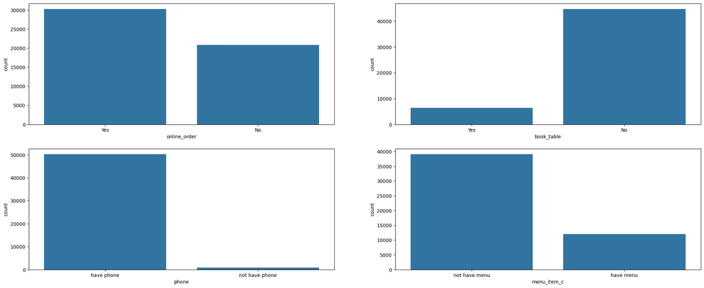

```python
#subplot has columns that have yes or no
plt.figure(figsize=(25,10))
for i,cat in enumerate(["online_order","book_table","phone","menu_item_c"],1):
    plt.subplot(2,2,i)
    sns.countplot(x=df_eda[cat])
```

```python
df_eda["location"].value_counts().head(10).reset_index()#test
```

|  | location | count |
| --- | --- | --- |
| 0 | BTM | 5056 |
| 1 | HSR | 2495 |
| 2 | Koramangala 5th Block | 2480 |
| 3 | JP Nagar | 2218 |
| 4 | Whitefield | 2107 |
| 5 | Indiranagar | 2033 |
| 6 | Jayanagar | 1916 |
| 7 | Marathahalli | 1808 |
| 8 | Bannerghatta Road | 1609 |
| 9 | Bellandur | 1268 |

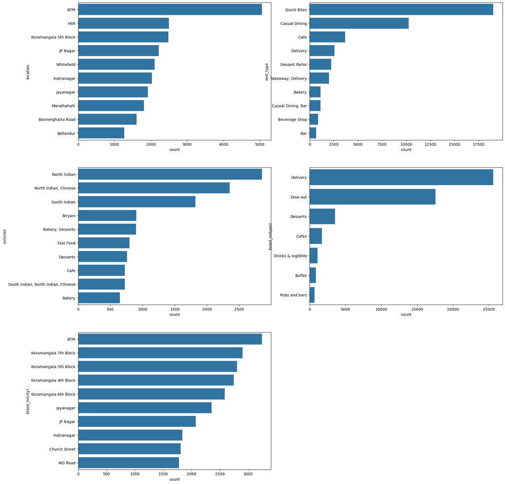

```python
#subplot of other  categorical columns, but get top 10 only
plt.figure(figsize=(20,30))
for i,cat in enumerate(categorical.drop(["name","online_order","book_table","phone","menu_item_c"]),1):
    plt.subplot(4,2,i)
    df_=df_eda[cat].value_counts().head(10).reset_index()
    sns.barplot(data=df_,y=cat,x="count")
```

```python
numerical=df.select_dtypes(exclude="object").columns
numerical
```

```
Index(['rate', 'votes', 'approx_cost(for two people)'], dtype='object')
```

```python
df_eda[numerical].describe().round(2)
```

|  | rate | votes | approx_cost(for two people) |
| --- | --- | --- | --- |
| count | 43421.00 | 51088.00 | 51088.00 |
| mean | 3.51 | 285.14 | 556.13 |
| std | 0.92 | 806.90 | 439.65 |
| min | 0.00 | 0.00 | 40.00 |
| 25% | 3.30 | 7.00 | 300.00 |
| 50% | 3.70 | 41.00 | 400.00 |
| 75% | 4.00 | 200.00 | 700.00 |
| max | 4.90 | 16832.00 | 6000.00 |

Note:

In rate there is no restaurant having rating of 5

somehow there is outliers in votes and approx_cost(for two people)

In this busniess case if restuarant rate > 3.75 will be Successful restaurant (1) , else will be Failed restaurant (0)

```python
df_eda.rate.isna().sum()
```

```
7667
```

```python
df_eda[df_eda.rate.isna()]
```

|  | name | online_order | book_table | rate | votes | phone | location | rest_type | cuisines | approx_cost(for two people) | reviews_list | listed_in(type) | listed_in(city) | menu_item_c |
| --- | --- | --- | --- | --- | --- | --- | --- | --- | --- | --- | --- | --- | --- | --- |
| 84 | Chill Out | No | No | NaN | 0 | have phone | Banashankari | Quick Bites | South Indian, Chinese | 100.0 | [('Rated 4.0', 'RATED\n Good Location. Small ... | Delivery | Banashankari | not have menu |
| 90 | Me And My Cake | No | No | NaN | 0 | have phone | Banashankari | Delivery | Bakery, Desserts | 500.0 | [('Rated 1.0', 'RATED\n Do not order anything... | Delivery | Banashankari | not have menu |
| 91 | Sunsadm | No | No | NaN | 0 | have phone | Banashankari | Takeaway, Delivery | South Indian | 400.0 | [] | Delivery | Banashankari | not have menu |
| 92 | Annapooraneshwari Mess | No | No | NaN | 0 | have phone | Banashankari | Mess | South Indian | 200.0 | [] | Delivery | Banashankari | not have menu |
| 107 | Coffee Shopee | No | No | NaN | 0 | have phone | Banashankari | Takeaway, Delivery | Beverages | 250.0 | [] | Delivery | Banashankari | not have menu |
| ... | ... | ... | ... | ... | ... | ... | ... | ... | ... | ... | ... | ... | ... | ... |
| 51644 | Punjabi Thadka | No | No | NaN | 0 | have phone | Brookefield | Quick Bites | North Indian | 400.0 | [] | Dine-out | Whitefield | not have menu |
| 51675 | Topsy Turvey | No | No | NaN | 0 | have phone | Whitefield | Bar | Finger Food | 900.0 | [('Rated 4.0', "RATED\n A divine joint for Fl... | Drinks & nightlife | Whitefield | not have menu |
| 51710 | Topsy Turvey | No | No | NaN | 0 | have phone | Whitefield | Bar | Finger Food | 900.0 | [('Rated 4.0', "RATED\n A divine joint for Fl... | Pubs and bars | Whitefield | not have menu |
| 51713 | Vinod Bar And Restaurant | No | No | NaN | 0 | have phone | Whitefield | Bar | Finger Food | 600.0 | [] | Pubs and bars | Whitefield | not have menu |
| 51714 | Plunge - Sheraton Grand Bengaluru Whitefield H... | No | No | NaN | 0 | not have phone | Whitefield | Bar | Finger Food | 2000.0 | [] | Pubs and bars | Whitefield | not have menu |

7667 rows × 14 columns

```python
def success(x):
        if x >3.75:
            return 1
        elif x  <= 3.75:
            return 0
        else:
            return np.nan

df_eda.rate.apply(success)
```

```
0        1.0
1        1.0
2        1.0
3        0.0
4        1.0
        ...
51712    0.0
51713    NaN
51714    NaN
51715    1.0
51716    0.0
Name: rate, Length: 51088, dtype: float64
```

```python
df_eda.rate=df_eda.rate.apply(success)
```

```python
df_eda.rate.value_counts()
```

```
rate
0.0    23356
1.0    20065
Name: count, dtype: int64
```

```python
# check outilers in votes

df_eda.votes.quantile([0.25,0.50,0.80,0.90,0.95,0.99,0.995,0.999,0.9995,1]).to_frame().T
```

|  | 0.2500 | 0.5000 | 0.8000 | 0.9000 | 0.9500 | 0.9900 | 0.9950 | 0.9990 | 0.9995 | 1.0000 |
| --- | --- | --- | --- | --- | --- | --- | --- | --- | --- | --- |
| votes | 7.0 | 41.0 | 283.0 | 712.0 | 1382.65 | 3849.39 | 4851.78 | 9080.0 | 10548.3695 | 16832.0 |

```python
fig=px.histogram(df_eda.votes)
fig.update_layout(title_text="Histgorm of votes",title_x=0.5)
```

[interactive chart not shown]

```python
fig=px.box(x=df_eda.votes)
fig.update_layout(title_text="Box plot of votes",title_x=0.5)
```

[interactive chart not shown]

```python
df_eda[df_eda.votes>=df_eda.votes.quantile(0.9995)]
```

|  | name | online_order | book_table | rate | votes | phone | location | rest_type | cuisines | approx_cost(for two people) | reviews_list | listed_in(type) | listed_in(city) | menu_item_c |
| --- | --- | --- | --- | --- | --- | --- | --- | --- | --- | --- | --- | --- | --- | --- |
| 3921 | Byg Brewski Brewing Company | Yes | Yes | 1.0 | 16345 | have phone | Sarjapur Road | Microbrewery | Continental, North Indian, Italian, South Indi... | 1600.0 | [('Rated 5.0', 'RATED\n I have been to this p... | Delivery | Bellandur | not have menu |
| 4801 | Byg Brewski Brewing Company | Yes | Yes | 1.0 | 16345 | have phone | Sarjapur Road | Microbrewery | Continental, North Indian, Italian, South Indi... | 1600.0 | [('Rated 5.0', 'RATED\n I have been to this p... | Dine-out | Bellandur | have menu |
| 4944 | Byg Brewski Brewing Company | Yes | Yes | 1.0 | 16345 | have phone | Sarjapur Road | Microbrewery | Continental, North Indian, Italian, South Indi... | 1600.0 | [('Rated 5.0', 'RATED\n I have been to this p... | Drinks & nightlife | Bellandur | have menu |
| 8330 | Truffles | No | No | 1.0 | 14654 | have phone | Koramangala 5th Block | Cafe, Casual Dining | Cafe, American, Burger, Steak | 900.0 | [('Rated 5.0', 'RATED\n Menu is extensive and... | Cafes | BTM | not have menu |
| 9807 | Truffles | No | No | 1.0 | 14654 | have phone | Koramangala 5th Block | Cafe, Casual Dining | Cafe, American, Burger, Steak | 900.0 | [('Rated 5.0', 'RATED\n Menu is extensive and... | Delivery | BTM | not have menu |
| 10860 | Truffles | No | No | 1.0 | 14654 | have phone | Koramangala 5th Block | Cafe, Casual Dining | Cafe, American, Burger, Steak | 900.0 | [('Rated 5.0', 'RATED\n Menu is extensive and... | Dine-out | BTM | not have menu |
| 18643 | Toit | No | No | 1.0 | 14956 | have phone | Indiranagar | Microbrewery | Italian, American, Pizza | 1500.0 | [('Rated 4.0', "RATED\n The crowd keeps flowi... | Dine-out | Indiranagar | not have menu |
| 19268 | Toit | No | No | 1.0 | 14956 | have phone | Indiranagar | Microbrewery | Italian, American, Pizza | 1500.0 | [('Rated 4.0', "RATED\n The crowd keeps flowi... | Drinks & nightlife | Indiranagar | not have menu |
| 26549 | Truffles | No | No | 1.0 | 14690 | have phone | Koramangala 5th Block | Cafe, Casual Dining | Cafe, American, Burger, Steak | 900.0 | [('Rated 4.0', 'RATED\n Package: 4/5\nFood: 4... | Cafes | Koramangala 4th Block | not have menu |
| 27806 | Truffles | No | No | 1.0 | 14694 | have phone | Koramangala 5th Block | Cafe, Casual Dining | Cafe, American, Burger, Steak | 900.0 | [('Rated 4.0', 'RATED\n Package: 4/5\nFood: 4... | Delivery | Koramangala 4th Block | not have menu |
| 28384 | Truffles | No | No | 1.0 | 14704 | have phone | Koramangala 5th Block | Cafe, Casual Dining | Cafe, American, Burger, Steak | 900.0 | [('Rated 2.0', "RATED\n Overhyped ! Deserts a... | Dine-out | Koramangala 4th Block | not have menu |
| 29303 | Truffles | No | No | 1.0 | 14710 | have phone | Koramangala 5th Block | Cafe, Casual Dining | Cafe, American, Burger, Steak | 900.0 | [('Rated 2.0', "RATED\n Overhyped ! Deserts a... | Cafes | Koramangala 5th Block | not have menu |
| 29414 | Truffles | No | No | 1.0 | 14710 | have phone | Koramangala 5th Block | Cafe, Casual Dining | Cafe, American, Burger, Steak | 900.0 | [('Rated 2.0', "RATED\n Overhyped ! Deserts a... | Delivery | Koramangala 5th Block | not have menu |
| 31055 | Truffles | No | No | 1.0 | 14710 | have phone | Koramangala 5th Block | Cafe, Casual Dining | Cafe, American, Burger, Steak | 900.0 | [('Rated 2.0', "RATED\n Overhyped ! Deserts a... | Dine-out | Koramangala 5th Block | not have menu |
| 32152 | Truffles | No | No | 1.0 | 14717 | have phone | Koramangala 5th Block | Cafe, Casual Dining | Cafe, American, Burger, Steak | 900.0 | [('Rated 2.0', "RATED\n Overhyped ! Deserts a... | Cafes | Koramangala 6th Block | not have menu |
| 33312 | Truffles | No | No | 1.0 | 14717 | have phone | Koramangala 5th Block | Cafe, Casual Dining | Cafe, American, Burger, Steak | 900.0 | [('Rated 2.0', "RATED\n Overhyped ! Deserts a... | Delivery | Koramangala 6th Block | not have menu |
| 33913 | Truffles | No | No | 1.0 | 14723 | have phone | Koramangala 5th Block | Cafe, Casual Dining | Cafe, American, Burger, Steak | 900.0 | [('Rated 3.0', "RATED\n Not bad but the burge... | Dine-out | Koramangala 6th Block | not have menu |
| 34779 | Truffles | No | No | 1.0 | 14723 | have phone | Koramangala 5th Block | Cafe, Casual Dining | Cafe, American, Burger, Steak | 900.0 | [('Rated 3.0', "RATED\n Not bad but the burge... | Cafes | Koramangala 7th Block | not have menu |
| 36000 | Truffles | No | No | 1.0 | 14723 | have phone | Koramangala 5th Block | Cafe, Casual Dining | Cafe, American, Burger, Steak | 900.0 | [('Rated 3.0', "RATED\n Not bad but the burge... | Delivery | Koramangala 7th Block | not have menu |
| 36668 | Truffles | No | No | 1.0 | 14726 | have phone | Koramangala 5th Block | Cafe, Casual Dining | Cafe, American, Burger, Steak | 900.0 | [('Rated 3.0', "RATED\n Not bad but the burge... | Dine-out | Koramangala 7th Block | not have menu |
| 37606 | The Black Pearl | No | Yes | 1.0 | 10550 | have phone | Koramangala 5th Block | Casual Dining, Bar | North Indian, European, Mediterranean | 1400.0 | [('Rated 5.0', 'RATED\n Amazing experience am... | Pubs and bars | Koramangala 7th Block | not have menu |
| 40506 | AB's - Absolute Barbecues | No | Yes | 1.0 | 12121 | have phone | Marathahalli | Casual Dining | European, Mediterranean, North Indian, BBQ | 1600.0 | [('Rated 4.0', 'RATED\n We came here for a te... | Buffet | Marathahalli | not have menu |
| 41525 | AB's - Absolute Barbecues | No | Yes | 1.0 | 12121 | have phone | Marathahalli | Casual Dining | European, Mediterranean, North Indian, BBQ | 1600.0 | [('Rated 4.0', 'RATED\n We came here for a te... | Dine-out | Marathahalli | not have menu |
| 49170 | Byg Brewski Brewing Company | Yes | Yes | 1.0 | 16832 | have phone | Sarjapur Road | Microbrewery | Continental, North Indian, Italian, South Indi... | 1600.0 | [('Rated 5.0', "RATED\n This is an absolute g... | Delivery | Sarjapur Road | not have menu |
| 49627 | Byg Brewski Brewing Company | Yes | Yes | 1.0 | 16832 | have phone | Sarjapur Road | Microbrewery | Continental, North Indian, Italian, South Indi... | 1600.0 | [('Rated 4.0', 'RATED\n Visiting a microbrewe... | Dine-out | Sarjapur Road | not have menu |
| 50059 | Byg Brewski Brewing Company | Yes | Yes | 1.0 | 16832 | have phone | Sarjapur Road | Microbrewery | Continental, North Indian, Italian, South Indi... | 1600.0 | [('Rated 4.0', 'RATED\n Visiting a microbrewe... | Drinks & nightlife | Sarjapur Road | not have menu |

```python
# check outilers in votes

df_eda["approx_cost(for two people)"].quantile([0.25,0.50,0.80,0.90,0.95,0.99,0.995,0.999,0.9995,1]).to_frame().T
```

|  | 0.2500 | 0.5000 | 0.8000 | 0.9000 | 0.9500 | 0.9900 | 0.9950 | 0.9990 | 0.9995 | 1.0000 |
| --- | --- | --- | --- | --- | --- | --- | --- | --- | --- | --- |
| approx_cost(for two people) | 300.0 | 400.0 | 750.0 | 1100.0 | 1500.0 | 2200.0 | 2800.0 | 3500.0 | 4000.0 | 6000.0 |

```python
fig=px.histogram(df_eda["approx_cost(for two people)"])
fig.update_layout(title_text="Histgorm of votes",title_x=0.5)
```

[interactive chart not shown]

```python
fig=px.box(x=df_eda["approx_cost(for two people)"])
fig.update_layout(title_text="Box plot of votes",title_x=0.5)
```

[interactive chart not shown]

yes. there are outiers , but its normal so dont drop any value but use Robust scale in preprocessing

### **Conclusion from Unviarate Analysis**

# **Bivarate**

- **Top 10 restaurant successful (rate=1)** (name,rate)
- **Relation between online_order and rate**
- **Relation between book_table and rate**
- **Average votes for rate**
- **Relation between phone and rate**
- **Top 10 locations that have a successful restaurant and Competition is high(rate=1)**
- **Top 10 locations with low competition (rate=0)**
- **Relation between list_in(city) and rate**
- **Top 10 rest_type has good reputation (rate=1)**
- **Top 10 cuisines has good reputation (rate=1)**
- **Relation between listed_in(type) and rate**
- **Average approx cost for rate**
- **Relation between menu_item and rate**
- **Correlation**
- **Conclusion**

```python
df_eda.head()
```

|  | name | online_order | book_table | rate | votes | phone | location | rest_type | cuisines | approx_cost(for two people) | reviews_list | listed_in(type) | listed_in(city) | menu_item_c |
| --- | --- | --- | --- | --- | --- | --- | --- | --- | --- | --- | --- | --- | --- | --- |
| 0 | Jalsa | Yes | Yes | 1.0 | 775 | have phone | Banashankari | Casual Dining | North Indian, Mughlai, Chinese | 800.0 | [('Rated 4.0', 'RATED\n A beautiful place to ... | Buffet | Banashankari | not have menu |
| 1 | Spice Elephant | Yes | No | 1.0 | 787 | have phone | Banashankari | Casual Dining | Chinese, North Indian, Thai | 800.0 | [('Rated 4.0', 'RATED\n Had been here for din... | Buffet | Banashankari | not have menu |
| 2 | San Churro Cafe | Yes | No | 1.0 | 918 | have phone | Banashankari | Cafe, Casual Dining | Cafe, Mexican, Italian | 800.0 | [('Rated 3.0', "RATED\n Ambience is not that ... | Buffet | Banashankari | not have menu |
| 3 | Addhuri Udupi Bhojana | No | No | 0.0 | 88 | have phone | Banashankari | Quick Bites | South Indian, North Indian | 300.0 | [('Rated 4.0', "RATED\n Great food and proper... | Buffet | Banashankari | not have menu |
| 4 | Grand Village | No | No | 1.0 | 166 | have phone | Basavanagudi | Casual Dining | North Indian, Rajasthani | 600.0 | [('Rated 4.0', 'RATED\n Very good restaurant ... | Buffet | Banashankari | not have menu |

```python
#convert datatype of rate to object to make easy in Visualization
df_eda.rate=df_eda.rate.astype("O")
```

```python
df_eda.rate.dtype
```

```
dtype('O')
```

```python
# Visualization Function
def bar(data_frame,x,y,title_text,color=None):
    fig=px.bar(data_frame=data_frame,x=x,y=y,color=color, barmode='group',text_auto="0.2s")
    fig.update_traces(textfont_size=12,textposition="outside")
    fig.update_layout(title_text=title_text,title_x=0.5)
    return fig
```

### **Top 10 restaurant successful (rate=1)** (name,rate)

```python
#pandas
data=df_eda[df_eda.rate==1].groupby("name")["rate"].count().reset_index().sort_values(by="rate",ascending=False).head(10)
data
```

|  | name | rate |
| --- | --- | --- |
| 1712 | Onesta | 85 |
| 787 | Empire Restaurant | 62 |
| 1804 | Polar Bear | 58 |
| 1216 | Kanti Sweets | 57 |
| 805 | Faasos | 55 |
| 2123 | Smally's Resto Cafe | 54 |
| 2261 | Sweet Truth | 53 |
| 615 | Corner House Ice Cream | 52 |
| 377 | Burger King | 46 |
| 2762 | eat.fit | 46 |

```python
bar(data,"name","rate","Top 10 restaurant successful (rate=1)")
```

[interactive chart not shown]

### **Relation between online_order and rate**

```python
#pandas
data=df_eda.groupby(["rate","online_order"]).agg({"online_order":"count"}).rename(columns={"online_order":"count"}).reset_index()
data
```

|  | rate | online_order | count |
| --- | --- | --- | --- |
| 0 | 0.0 | No | 9229 |
| 1 | 0.0 | Yes | 14127 |
| 2 | 1.0 | No | 6033 |
| 3 | 1.0 | Yes | 14032 |

```python
bar(data,"rate","count",color="online_order",title_text="Relation between online_order and rate")
```

[interactive chart not shown]

- To be sucessful restaurant one should offer online_order service

### **Relation between book_table and rate**

```python
#pandas
data=df_eda.groupby(["rate","book_table"]).agg({"book_table":"count"}).rename(columns={"book_table":"count"}).reset_index()
data
```

|  | rate | book_table | count |
| --- | --- | --- | --- |
| 0 | 0.0 | No | 22755 |
| 1 | 0.0 | Yes | 601 |
| 2 | 1.0 | No | 14243 |
| 3 | 1.0 | Yes | 5822 |

```python
bar(data,"rate","count",color="book_table",title_text="Relation between book_table and rate")
```

[interactive chart not shown]

### **Average votes for rate**

```python
data=df_eda.groupby("rate")["votes"].mean().reset_index()
data
```

|  | rate | votes |
| --- | --- | --- |
| 0 | 0.0 | 58.324114 |
| 1 | 1.0 | 657.110441 |

```python
bar(data,"rate","votes","Average votes for rate")
```

[interactive chart not shown]

- Most successful restaurant have more votes

### **Relation between phone and rate**

```python
#pandas
data=df_eda.groupby(["rate","phone"]).agg({"phone":"count"}).rename(columns={"phone":"count"}).reset_index()
data
```

|  | rate | phone | count |
| --- | --- | --- | --- |
| 0 | 0.0 | have phone | 23004 |
| 1 | 0.0 | not have phone | 352 |
| 2 | 1.0 | have phone | 19828 |
| 3 | 1.0 | not have phone | 237 |

```python
bar(data,"rate","count",color="phone",title_text="Relation between phone and rate")
```

[interactive chart not shown]

- To open any resturant must have phone number

### **Top 10 locations that have a successful restaurant and Competition is high((rate=1)**

```python
#pandas
data=df_eda[df_eda.rate==1].groupby("location")["rate"].count().reset_index().sort_values(by="rate",ascending=False).head(10)
data
```

|  | location | rate |
| --- | --- | --- |
| 43 | Koramangala 5th Block | 1766 |
| 0 | BTM | 1207 |
| 26 | Indiranagar | 1183 |
| 21 | HSR | 975 |
| 30 | Jayanagar | 955 |
| 28 | JP Nagar | 830 |
| 45 | Koramangala 7th Block | 689 |
| 82 | Whitefield | 628 |
| 44 | Koramangala 6th Block | 614 |
| 42 | Koramangala 4th Block | 613 |

```python
bar(data,"location","rate",title_text="Top 10 locations that have a successful restaurant and Competition is high((rate=1)")
```

[interactive chart not shown]

- Koramangala 5th Block, BTM and Indiranagar have successful restaurant and Competition is high.

### **Top 10 locations with low competition (rate=0)**

```python
#pandas
data=df_eda[df_eda.rate==0].groupby("location")["rate"].count().reset_index().sort_values(by="rate",ascending=False).tail(10)
data
```

|  | location | rate |
| --- | --- | --- |
| 83 | Uttarahalli | 9 |
| 11 | Central Bangalore | 8 |
| 38 | Kengeri | 7 |
| 23 | Hebbal | 6 |
| 49 | Langford Town | 5 |
| 87 | West Bangalore | 5 |
| 90 | Yelahanka | 2 |
| 63 | Peenya | 1 |
| 57 | Nagarbhavi | 1 |
| 67 | Rajarajeshwari Nagar | 1 |

```python
bar(data,"location","rate",title_text="Top 10 locations with low competition (rate=0)")
```

[interactive chart not shown]

- in Rajarajeshwari Nagar, Peenya and Nagarabhavi competition is low
- **opinion**: you can open resturant in Rajarajeshwari Nagar, Peenya or Nagarabhavi that have lower competition make good reputation after that open in Koramangala 5th Block or BTM that have higher competition.

### **Relation between list_in(city) and rate**

```python
#pandas
data=df_eda.groupby(["rate","listed_in(city)"]).agg({"listed_in(city)":"count"}).rename(columns={"listed_in(city)":"count"}).reset_index().sort_values(by="count",ascending=False)
data
```

|  | rate | listed_in(city) | count |
| --- | --- | --- | --- |
| 0 | 0.0 | BTM | 1496 |
| 49 | 1.0 | Koramangala 7th Block | 1257 |
| 30 | 1.0 | BTM | 1251 |
| 19 | 0.0 | Koramangala 7th Block | 1217 |
| 47 | 1.0 | Koramangala 5th Block | 1194 |
| 46 | 1.0 | Koramangala 4th Block | 1194 |
| 17 | 0.0 | Koramangala 5th Block | 1182 |
| 16 | 0.0 | Koramangala 4th Block | 1159 |
| 48 | 1.0 | Koramangala 6th Block | 1135 |
| 12 | 0.0 | JP Nagar | 1082 |
| 18 | 0.0 | Koramangala 6th Block | 1075 |
| 13 | 0.0 | Jayanagar | 1063 |
| 43 | 1.0 | Jayanagar | 931 |
| 23 | 0.0 | Marathahalli | 912 |
| 2 | 0.0 | Bannerghatta Road | 911 |
| 37 | 1.0 | Church Street | 902 |
| 51 | 1.0 | MG Road | 901 |
| 35 | 1.0 | Brigade Road | 887 |
| 41 | 1.0 | Indiranagar | 859 |
| 6 | 0.0 | Brookefield | 851 |
| 10 | 0.0 | HSR | 826 |
| 50 | 1.0 | Lavelle Road | 819 |
| 11 | 0.0 | Indiranagar | 794 |
| 57 | 1.0 | Residency Road | 775 |
| 29 | 0.0 | Whitefield | 767 |
| 8 | 0.0 | Electronic City | 730 |
| 42 | 1.0 | JP Nagar | 680 |
| 20 | 0.0 | Lavelle Road | 671 |
| 7 | 0.0 | Church Street | 667 |
| 28 | 0.0 | Sarjapur Road | 661 |
| 5 | 0.0 | Brigade Road | 650 |
| 21 | 0.0 | MG Road | 650 |
| 14 | 0.0 | Kalyan Nagar | 645 |
| 4 | 0.0 | Bellandur | 642 |
| 15 | 0.0 | Kammanahalli | 623 |
| 55 | 1.0 | Old Airport Road | 619 |
| 40 | 1.0 | HSR | 618 |
| 25 | 0.0 | Old Airport Road | 606 |
| 27 | 0.0 | Residency Road | 602 |
| 3 | 0.0 | Basavanagudi | 576 |
| 33 | 1.0 | Basavanagudi | 549 |
| 26 | 0.0 | Rajajinagar | 514 |
| 9 | 0.0 | Frazer Town | 502 |
| 22 | 0.0 | Malleshwaram | 502 |
| 39 | 1.0 | Frazer Town | 491 |
| 59 | 1.0 | Whitefield | 482 |
| 52 | 1.0 | Malleshwaram | 472 |
| 45 | 1.0 | Kammanahalli | 441 |
| 53 | 1.0 | Marathahalli | 434 |
| 44 | 1.0 | Kalyan Nagar | 424 |
| 1 | 0.0 | Banashankari | 424 |
| 32 | 1.0 | Bannerghatta Road | 412 |
| 36 | 1.0 | Brookefield | 398 |
| 58 | 1.0 | Sarjapur Road | 393 |
| 34 | 1.0 | Bellandur | 388 |
| 56 | 1.0 | Rajajinagar | 381 |
| 24 | 0.0 | New BEL Road | 356 |
| 31 | 1.0 | Banashankari | 342 |
| 54 | 1.0 | New BEL Road | 228 |
| 38 | 1.0 | Electronic City | 208 |

```python
data.rate=data.rate.astype("O")
```

```python
bar(data,"listed_in(city)","count",color="rate",title_text="Relation between list_in(city) and rate")
```

[interactive chart not shown]

- **Conclusion**:

BTM , Koramangala 7th Block and Koramangala 5th Block, have the highest percentage of restaurant successful or failed , so competition is very high

### **Top 10 rest_type has good reputation (rate=1)**

```python
#pandas
data=df_eda[df_eda.rate==1].groupby("rest_type")["rate"].count().reset_index().sort_values(by="rate",ascending=False).head(10)
data
```

|  | rest_type | rate |
| --- | --- | --- |
| 21 | Casual Dining | 5490 |
| 62 | Quick Bites | 4275 |
| 13 | Cafe | 2225 |
| 32 | Dessert Parlor | 1240 |
| 22 | Casual Dining, Bar | 893 |
| 31 | Delivery | 586 |
| 4 | Bar | 358 |
| 5 | Bar, Casual Dining | 326 |
| 37 | Fine Dining | 313 |
| 71 | Takeaway, Delivery | 310 |

```python
bar(data,"rest_type","rate",title_text="Top 10 rest_type has good reputation (rate=1)")
```

[interactive chart not shown]

- To be successful restaurant you have to rest type will be Casual Dining or Quick Bites

### **Top 10 cuisines has good reputation (rate=1)**

```python
#pandas
data=df_eda[df_eda.rate==1].groupby("cuisines")["rate"].count().reset_index().sort_values(by="rate",ascending=False).head(10)
data
```

|  | cuisines | rate |
| --- | --- | --- |
| 1047 | North Indian | 816 |
| 1379 | South Indian | 408 |
| 1080 | North Indian, Chinese | 392 |
| 681 | Desserts | 336 |
| 156 | Bakery, Desserts | 290 |
| 285 | Cafe | 287 |
| 859 | Ice Cream, Desserts | 236 |
| 687 | Desserts, Beverages | 205 |
| 1421 | South Indian, North Indian, Chinese | 190 |
| 1017 | Mithai, Street Food | 168 |

```python
bar(data,"cuisines","rate",title_text="Top 10 cuisines has good reputation (rate=1)")
```

[interactive chart not shown]

- To be successful restaurant you have to cuisines type will be North Indian or Chinese or South Indian

### **Average approx cost for rate**

```python
data=df_eda.groupby("rate")["approx_cost(for two people)"].mean().reset_index()
data
```

|  | rate | approx_cost(for two people) |
| --- | --- | --- |
| 0 | 0.0 | 442.067392 |
| 1 | 1.0 | 773.866434 |

```python
bar(data,"rate","approx_cost(for two people)","Average approx cost for rate")
```

[interactive chart not shown]

### **Relation between listed_in(type) and rate**

```python
#pandas
data=df_eda.groupby(["rate","listed_in(type)"]).agg({"listed_in(type)":"count"}).rename(columns={"listed_in(type)":"count"}).reset_index().sort_values(by="count",ascending=False
                                                                                                                                                      )
data
```

|  | rate | listed_in(type) | count |
| --- | --- | --- | --- |
| 2 | 0.0 | Delivery | 12601 |
| 9 | 1.0 | Delivery | 8981 |
| 4 | 0.0 | Dine-out | 8229 |
| 11 | 1.0 | Dine-out | 6577 |
| 10 | 1.0 | Desserts | 1490 |
| 3 | 0.0 | Desserts | 1356 |
| 8 | 1.0 | Cafes | 1010 |
| 12 | 1.0 | Drinks & nightlife | 829 |
| 7 | 1.0 | Buffet | 676 |
| 1 | 0.0 | Cafes | 579 |
| 13 | 1.0 | Pubs and bars | 502 |
| 5 | 0.0 | Drinks & nightlife | 244 |
| 0 | 0.0 | Buffet | 189 |
| 6 | 0.0 | Pubs and bars | 158 |

```python
data.rate=data.rate.astype("O")
```

```python
bar(data,"listed_in(type)","count",color="rate",title_text="Relation between listed_in(type) and rate")
```

[interactive chart not shown]

The type of service provided by the most resturants either successful or failed is Delivery or Dine-out.

## - To be successful restaurant one has to provide service of Delivery or Dine-out

### **Relation between menu_item and rate**

```python
#pandas
data=df_eda.groupby(["rate","menu_item_c"]).agg({"menu_item_c":"count"}).rename(columns={"menu_item_c":"count"}).reset_index()
data
```

|  | rate | menu_item_c | count |
| --- | --- | --- | --- |
| 0 | 0.0 | have menu | 5401 |
| 1 | 0.0 | not have menu | 17955 |
| 2 | 1.0 | have menu | 5932 |
| 3 | 1.0 | not have menu | 14133 |

```python
bar(data,"rate","count",color="menu_item_c",title_text="Relation between menu_item and rate")
```

[interactive chart not shown]

- There is no relation between successful or failed restaurant have menu or not , but for restaurant to be successful perfer put menu.

## **Correlation**

```python
df_eda[numerical].corr()
```

|  | rate | votes | approx_cost(for two people) |
| --- | --- | --- | --- |
| rate | 1.000000 | 0.344999 | 0.359934 |
| votes | 0.344999 | 1.000000 | 0.381649 |
| approx_cost(for two people) | 0.359934 | 0.381649 | 1.000000 |

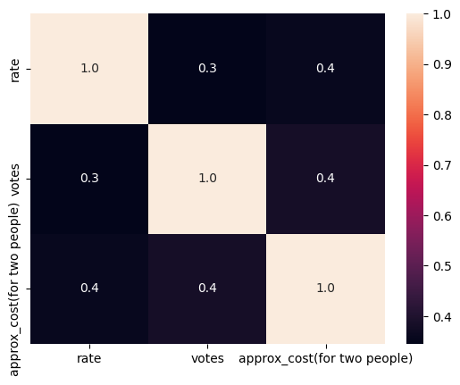

```python
sns.heatmap(df_eda[numerical].corr(),annot=True, fmt=".1f")
```

- There is positive relation between rate and (votes , approx_cost(for two people))

### **Conclusion for Bivarate :**

**Some advice to be a successful restaurant :**

1) online_order service is available

2) must have phone number

4) Must have restaurant type will be Casual Dining or Quick Bites

5) Must have cuisines type will be North Indian or Chinese or South Indian

6) prefer put menu in website

7) service provided should be Delivery or Dine-out

# **Multivarate**

- **Top 10 restuarant have good vote**(name,rate=1,vote)
- **Lowest 10 restuarant have bad vote**(name,rate=0,vote)
- **Relation between location and rest_type for rate**
- **Relation between location and cuisines for rate**
- **Relation between location and approx_cost for rate**
- **Relation between location and listed_in(type) for rate**

### **Top 10 restuarant have good vote**(name,rate=1,vote)

```python
data=df_eda[df_eda.rate==1].groupby("name")["votes"].mean().reset_index().sort_values(by="votes",ascending=False).head(10)
data
```

|  | name | votes |
| --- | --- | --- |
| 386 | Byg Brewski Brewing Company | 16588.500000 |
| 2569 | Toit | 14956.000000 |
| 2357 | The Black Pearl | 9562.333333 |
| 283 | Big Pitcher | 9164.500000 |
| 131 | Arbor Brewing Company | 8396.545455 |
| 1825 | Prost Brew Pub | 7860.900000 |
| 576 | Church Street Social | 7561.727273 |
| 1022 | Hoot | 7257.000000 |
| 2419 | The Hole in the Wall Cafe | 7124.875000 |
| 2578 | Truffles | 7001.372093 |

```python
bar(data,"name",'votes',"Top 10 restuarant have good vote (name,rate=1,vote)")
```

[interactive chart not shown]

```python
data=df_eda[df_eda.rate==0].groupby("name")["votes"].mean().reset_index().sort_values(by="votes",ascending=False).head(10)
data
```

|  | name | votes |
| --- | --- | --- |
| 464 | Barleyz | 4651.750000 |
| 1628 | Golkonda Chimney | 1818.500000 |
| 4803 | Xtreme Sports Bar | 1114.500000 |
| 428 | Banana Beach Bar | 1014.687500 |
| 2757 | Moriz Restaurant | 959.375000 |
| 1201 | Delhi Food Point | 910.700000 |
| 83 | Aalishan Restaurant & Caterer | 888.454545 |
| 3138 | Orzuv | 837.000000 |
| 2527 | M.M.A. Kabab's & Biriyani Center | 795.500000 |
| 2518 | Luo Han | 777.000000 |

```python
bar(data,"name",'votes',"Lowest 10 restuarant have bad vote (name,rate=0,vote)")
```

[interactive chart not shown]

### **Relation between location and rest_type for rate**

```python
df_eda.head(5)
```

|  | name | online_order | book_table | rate | votes | phone | location | rest_type | cuisines | approx_cost(for two people) | reviews_list | listed_in(type) | listed_in(city) | menu_item_c |
| --- | --- | --- | --- | --- | --- | --- | --- | --- | --- | --- | --- | --- | --- | --- |
| 0 | Jalsa | Yes | Yes | 1.0 | 775 | have phone | Banashankari | Casual Dining | North Indian, Mughlai, Chinese | 800.0 | [('Rated 4.0', 'RATED\n A beautiful place to ... | Buffet | Banashankari | not have menu |
| 1 | Spice Elephant | Yes | No | 1.0 | 787 | have phone | Banashankari | Casual Dining | Chinese, North Indian, Thai | 800.0 | [('Rated 4.0', 'RATED\n Had been here for din... | Buffet | Banashankari | not have menu |
| 2 | San Churro Cafe | Yes | No | 1.0 | 918 | have phone | Banashankari | Cafe, Casual Dining | Cafe, Mexican, Italian | 800.0 | [('Rated 3.0', "RATED\n Ambience is not that ... | Buffet | Banashankari | not have menu |
| 3 | Addhuri Udupi Bhojana | No | No | 0.0 | 88 | have phone | Banashankari | Quick Bites | South Indian, North Indian | 300.0 | [('Rated 4.0', "RATED\n Great food and proper... | Buffet | Banashankari | not have menu |
| 4 | Grand Village | No | No | 1.0 | 166 | have phone | Basavanagudi | Casual Dining | North Indian, Rajasthani | 600.0 | [('Rated 4.0', 'RATED\n Very good restaurant ... | Buffet | Banashankari | not have menu |

```python
#pandas
data=df_eda.groupby(["rate","location","rest_type"]).agg({"rest_type":"count"}).rename(columns={"rest_type":"count"}).reset_index().sort_values(by="count",ascending=False).head(20)
data
```

|  | rate | location | rest_type | count |
| --- | --- | --- | --- | --- |
| 14 | 0.0 | BTM | Quick Bites | 1694 |
| 954 | 1.0 | BTM | Quick Bites | 477 |
| 1421 | 1.0 | Koramangala 5th Block | Casual Dining | 442 |
| 650 | 0.0 | Marathahalli | Quick Bites | 439 |
| 910 | 0.0 | Whitefield | Quick Bites | 430 |
| 75 | 0.0 | Bannerghatta Road | Quick Bites | 417 |
| 308 | 0.0 | HSR | Quick Bites | 409 |
| 410 | 0.0 | Jayanagar | Quick Bites | 403 |
| 7 | 0.0 | BTM | Casual Dining | 367 |
| 385 | 0.0 | JP Nagar | Quick Bites | 364 |
| 1249 | 1.0 | Indiranagar | Casual Dining | 343 |
| 262 | 0.0 | Electronic City | Quick Bites | 332 |
| 1417 | 1.0 | Koramangala 5th Block | Cafe | 326 |
| 485 | 0.0 | Koramangala 1st Block | Quick Bites | 323 |
| 1310 | 1.0 | Jayanagar | Casual Dining | 310 |
| 1209 | 1.0 | HSR | Quick Bites | 309 |
| 946 | 1.0 | BTM | Casual Dining | 302 |
| 134 | 0.0 | Bellandur | Quick Bites | 291 |
| 298 | 0.0 | HSR | Casual Dining | 279 |
| 1285 | 1.0 | JP Nagar | Casual Dining | 271 |

```python
data.rate=data.rate.astype("O")
```

```python
def sunburst(data,names,path,values,title_text):
    fig=px.sunburst(data_frame=data,names=names,path=path,values=values,
               width=900,height=900)
    fig.update_traces(textinfo="label+percent parent")
    fig.update_layout(title_text=title_text,title_x=0.5)
    return fig
```

```python
sunburst(data,"rate",["rate","location","rest_type"],"count","Relation between location and rest_type for rate")
```

[interactive chart not shown]

**Note:**

### **Relation between location and cuisines for rate**

```python
#pandas
data=df_eda.groupby(["rate","location","cuisines"]).agg({"cuisines":"count"}).rename(columns={"cuisines":"count"}).reset_index().sort_values(by="count",ascending=False).head(30)
data
```

|  | rate | location | cuisines | count |
| --- | --- | --- | --- | --- |
| 164 | 0.0 | BTM | North Indian, Chinese | 299 |
| 153 | 0.0 | BTM | North Indian | 202 |
| 4155 | 0.0 | Whitefield | North Indian | 113 |
| 528 | 0.0 | Bannerghatta Road | North Indian, Chinese | 97 |
| 3109 | 0.0 | Marathahalli | North Indian, Chinese | 95 |
| 93 | 0.0 | BTM | Fast Food | 91 |
| 770 | 0.0 | Bellandur | North Indian | 89 |
| 2036 | 0.0 | JP Nagar | North Indian | 84 |
| 3101 | 0.0 | Marathahalli | North Indian | 77 |
| 80 | 0.0 | BTM | Chinese, North Indian | 76 |
| 4161 | 0.0 | Whitefield | North Indian, Chinese | 74 |
| 2505 | 0.0 | Koramangala 1st Block | North Indian | 70 |
| 6449 | 1.0 | Koramangala 7th Block | North Indian | 69 |
| 1642 | 0.0 | HSR | North Indian, Chinese | 68 |
| 1345 | 0.0 | Electronic City | North Indian, Chinese | 66 |
| 2206 | 0.0 | Jayanagar | South Indian | 63 |
| 40 | 0.0 | BTM | Biryani | 62 |
| 5272 | 1.0 | HSR | North Indian | 61 |
| 776 | 0.0 | Bellandur | North Indian, Chinese | 61 |
| 4394 | 1.0 | BTM | North Indian | 58 |
| 51 | 0.0 | BTM | Biryani, North Indian | 58 |
| 1638 | 0.0 | HSR | North Indian | 55 |
| 4660 | 1.0 | Basavanagudi | South Indian | 54 |
| 3820 | 0.0 | Shivajinagar | South Indian | 54 |
| 5682 | 1.0 | JP Nagar | North Indian | 51 |
| 3923 | 0.0 | Ulsoor | North Indian, Chinese | 50 |
| 6263 | 1.0 | Koramangala 5th Block | Desserts | 50 |
| 1884 | 0.0 | Indiranagar | North Indian, Chinese | 50 |
| 207 | 0.0 | BTM | South Indian | 48 |
| 220 | 0.0 | BTM | South Indian, North Indian, Chinese | 47 |

```python
sunburst(data,"rate",["rate","location","cuisines"],"count","Relation between location and cuisines for rate")
```

[interactive chart not shown]

**Note:**

### **Relation between location and approx_cost for rate**

```python
data=df_eda.groupby(["rate","location"])["approx_cost(for two people)"].mean().reset_index().sort_values(by="approx_cost(for two people)",ascending=False).head(20)
data
```

|  | rate | location | approx_cost(for two people) |
| --- | --- | --- | --- |
| 162 | 1.0 | Sankey Road | 2802.941176 |
| 74 | 0.0 | Sankey Road | 2166.666667 |
| 142 | 1.0 | MG Road | 1495.551601 |
| 141 | 1.0 | Lavelle Road | 1450.970874 |
| 153 | 1.0 | Race Course Road | 1415.322581 |
| 119 | 1.0 | Infantry Road | 1251.111111 |
| 65 | 0.0 | Race Course Road | 1232.666667 |
| 157 | 1.0 | Residency Road | 1160.732323 |
| 158 | 1.0 | Richmond Road | 1137.257618 |
| 150 | 1.0 | Old Airport Road | 1135.120482 |
| 170 | 1.0 | Ulsoor | 1119.958848 |
| 107 | 1.0 | Domlur | 1041.007194 |
| 140 | 1.0 | Langford Town | 1000.000000 |
| 106 | 1.0 | Cunningham Road | 986.212121 |
| 168 | 1.0 | St. Marks Road | 966.356877 |
| 172 | 1.0 | Vasanth Nagar | 953.271028 |
| 174 | 1.0 | Whitefield | 947.452229 |
| 23 | 0.0 | Hebbal | 933.333333 |
| 133 | 1.0 | Koramangala 3rd Block | 931.962025 |
| 159 | 1.0 | Sadashiv Nagar | 912.500000 |

```python
data.rate=data.rate.astype("O")
```

```python
bar(data,"location","approx_cost(for two people)",color="rate",title_text="Relation between location and approx_cost for rate")
```

[interactive chart not shown]

**Note:**

- In Sankey Road has higher approx_cost(for two people) may be Sankey Road has expensive resturant

### **Relation between location and listed_in(type) for rate**

```python
#pandas
data=df_eda.groupby(["rate","location","listed_in(type)"]).agg({"listed_in(type)":"count"}).rename(columns={"listed_in(type)":"count"}).reset_index().sort_values(by="count",ascending=False).head(30)
data
```

|  | rate | location | listed_in(type) | count |
| --- | --- | --- | --- | --- |
| 2 | 0.0 | BTM | Delivery | 1848 |
| 4 | 0.0 | BTM | Dine-out | 979 |
| 115 | 0.0 | HSR | Delivery | 777 |
| 414 | 1.0 | BTM | Delivery | 766 |
| 621 | 1.0 | Koramangala 5th Block | Delivery | 690 |
| 524 | 1.0 | HSR | Delivery | 639 |
| 623 | 1.0 | Koramangala 5th Block | Dine-out | 581 |
| 546 | 1.0 | Indiranagar | Delivery | 575 |
| 263 | 0.0 | Marathahalli | Delivery | 567 |
| 147 | 0.0 | JP Nagar | Delivery | 544 |
| 395 | 0.0 | Whitefield | Delivery | 543 |
| 567 | 1.0 | Jayanagar | Delivery | 520 |
| 20 | 0.0 | Bannerghatta Road | Delivery | 501 |
| 135 | 0.0 | Indiranagar | Delivery | 429 |
| 157 | 0.0 | Jayanagar | Delivery | 427 |
| 397 | 0.0 | Whitefield | Dine-out | 401 |
| 559 | 1.0 | JP Nagar | Delivery | 394 |
| 22 | 0.0 | Bannerghatta Road | Dine-out | 370 |
| 265 | 0.0 | Marathahalli | Dine-out | 355 |
| 37 | 0.0 | Bellandur | Delivery | 354 |
| 99 | 0.0 | Electronic City | Delivery | 345 |
| 416 | 1.0 | BTM | Dine-out | 336 |
| 188 | 0.0 | Koramangala 1st Block | Delivery | 334 |
| 149 | 0.0 | JP Nagar | Dine-out | 327 |
| 335 | 0.0 | Sarjapur Road | Delivery | 315 |
| 101 | 0.0 | Electronic City | Dine-out | 309 |
| 207 | 0.0 | Koramangala 5th Block | Delivery | 303 |
| 548 | 1.0 | Indiranagar | Dine-out | 298 |
| 39 | 0.0 | Bellandur | Dine-out | 297 |
| 635 | 1.0 | Koramangala 7th Block | Delivery | 277 |

```python
sunburst(data,"rate",["rate","location","listed_in(type)"],"count","Relation between location and listed_in(type) for rate")
```

[interactive chart not shown]

**Note:**

- Higher percentage for listed_in(type) to all rate in any location is **Delivery**

**Preprocessing**

**in preprocessing**

- drop name , reviews_list and votes because its dont mean any thing in business case
- Impute missing value
- DataFrame after preprocessing
- create Pipeline content all steps of preprocessing

```python
df_pre=df_eda.copy()
```

```python
df_pre.head()
```

|  | name | online_order | book_table | rate | votes | phone | location | rest_type | cuisines | approx_cost(for two people) | reviews_list | listed_in(type) | listed_in(city) | menu_item_c |
| --- | --- | --- | --- | --- | --- | --- | --- | --- | --- | --- | --- | --- | --- | --- |
| 0 | Jalsa | Yes | Yes | 1.0 | 775 | have phone | Banashankari | Casual Dining | North Indian, Mughlai, Chinese | 800.0 | [('Rated 4.0', 'RATED\n A beautiful place to ... | Buffet | Banashankari | not have menu |
| 1 | Spice Elephant | Yes | No | 1.0 | 787 | have phone | Banashankari | Casual Dining | Chinese, North Indian, Thai | 800.0 | [('Rated 4.0', 'RATED\n Had been here for din... | Buffet | Banashankari | not have menu |
| 2 | San Churro Cafe | Yes | No | 1.0 | 918 | have phone | Banashankari | Cafe, Casual Dining | Cafe, Mexican, Italian | 800.0 | [('Rated 3.0', "RATED\n Ambience is not that ... | Buffet | Banashankari | not have menu |
| 3 | Addhuri Udupi Bhojana | No | No | 0.0 | 88 | have phone | Banashankari | Quick Bites | South Indian, North Indian | 300.0 | [('Rated 4.0', "RATED\n Great food and proper... | Buffet | Banashankari | not have menu |
| 4 | Grand Village | No | No | 1.0 | 166 | have phone | Basavanagudi | Casual Dining | North Indian, Rajasthani | 600.0 | [('Rated 4.0', 'RATED\n Very good restaurant ... | Buffet | Banashankari | not have menu |

```python
#1) drop name because its doesn't mean any thing in business case
df_pre.drop(["name","reviews_list","votes"],axis=1,inplace=True)
```

```python
df_pre.head()
```

|  | online_order | book_table | rate | phone | location | rest_type | cuisines | approx_cost(for two people) | listed_in(type) | listed_in(city) | menu_item_c |
| --- | --- | --- | --- | --- | --- | --- | --- | --- | --- | --- | --- |
| 0 | Yes | Yes | 1.0 | have phone | Banashankari | Casual Dining | North Indian, Mughlai, Chinese | 800.0 | Buffet | Banashankari | not have menu |
| 1 | Yes | No | 1.0 | have phone | Banashankari | Casual Dining | Chinese, North Indian, Thai | 800.0 | Buffet | Banashankari | not have menu |
| 2 | Yes | No | 1.0 | have phone | Banashankari | Cafe, Casual Dining | Cafe, Mexican, Italian | 800.0 | Buffet | Banashankari | not have menu |
| 3 | No | No | 0.0 | have phone | Banashankari | Quick Bites | South Indian, North Indian | 300.0 | Buffet | Banashankari | not have menu |
| 4 | No | No | 1.0 | have phone | Basavanagudi | Casual Dining | North Indian, Rajasthani | 600.0 | Buffet | Banashankari | not have menu |

```python
df_pre.columns
```

```
Index(['online_order', 'book_table', 'rate', 'phone', 'location', 'rest_type',
       'cuisines', 'approx_cost(for two people)', 'listed_in(type)',
       'listed_in(city)', 'menu_item_c'],
      dtype='object')
```

```python
!pip install category_encoders
from sklearn.pipeline import Pipeline
from sklearn.compose import ColumnTransformer
from sklearn.preprocessing import OneHotEncoder
from category_encoders import BinaryEncoder
from sklearn.impute import KNNImputer
from sklearn.preprocessing import RobustScaler
from sklearn.linear_model import LogisticRegression
from sklearn.svm import SVC
from sklearn.neighbors import KNeighborsClassifier
from sklearn.tree import DecisionTreeClassifier
from sklearn.ensemble import RandomForestClassifier
from sklearn.ensemble import GradientBoostingClassifier
from xgboost import XGBClassifier
from sklearn.model_selection import GridSearchCV
from sklearn.model_selection import cross_validate
from sklearn.model_selection import cross_val_score
```

```
     ━━━━━━━━━━━━━━━━━━━━━━━━━━━━━━━━━━━━━━━━ 81.9/81.9 kB 2.7 MB/s eta 0:00:00
```

```python
# !pip install category_encoders
```

```python
col_onehot=['online_order', 'book_table', 'phone','menu_item_c'] #columns that apply one hot encoder
col_binary=['location','rest_type', 'cuisines', 'listed_in(type)', 'listed_in(city)']#columns that apply binary encoder
col_robust=['approx_cost(for two people)']#columns that apply Robust scaler
```

**Impute missing value**

```python
#first create piepline to convert all categorcail to numerical
ct=ColumnTransformer([
    ("oh",OneHotEncoder(),col_onehot),
    ("binary",BinaryEncoder(),col_binary)
])
pipline=Pipeline(steps=[
    ("ct",ct)
])
```

```python
encoder=pipline.fit_transform(df_pre)
encoder #array represented to dataframe after enconder and this array not included in col_robust and rate
```

```
array([[0., 1., 0., ..., 0., 0., 1.],
       [0., 1., 1., ..., 0., 0., 1.],
       [0., 1., 1., ..., 0., 0., 1.],
       ...,
       [1., 0., 1., ..., 1., 1., 0.],
       [1., 0., 0., ..., 1., 1., 0.],
       [1., 0., 1., ..., 1., 1., 0.]])
```

```python
robust_array=np.array(df_pre[col_robust])
robust_array
```

```
array([[ 800.],
       [ 800.],
       [ 800.],
       ...,
       [2000.],
       [2500.],
       [1500.]])
```

```python
robust_array.shape
```

```
(51088, 1)
```

```python
rate_array=np.array(df.rate).reshape(-1,1) #i will take rate of df before conert rate to 0,1
rate_array
```

```
array([[4.1],
       [4.1],
       [3.8],
       ...,
       [nan],
       [4.3],
       [3.4]])
```

```python
rate_array.shape
```

```
(51088, 1)
```

```python
num_array=np.concatenate((robust_array,rate_array),axis=1) #concatenate columns in data (votes','approx_cost(for two people) , rate)
num_array
```

```
array([[ 800. ,    4.1],
       [ 800. ,    4.1],
       [ 800. ,    3.8],
       ...,
       [2000. ,    nan],
       [2500. ,    4.3],
       [1500. ,    3.4]])
```

```python
data_array=np.concatenate((encoder,num_array),axis=1) # array of data after making encoder enable to impute missing value
data_array
```

```
array([[0.0e+00, 1.0e+00, 0.0e+00, ..., 1.0e+00, 8.0e+02, 4.1e+00],
       [0.0e+00, 1.0e+00, 1.0e+00, ..., 1.0e+00, 8.0e+02, 4.1e+00],
       [0.0e+00, 1.0e+00, 1.0e+00, ..., 1.0e+00, 8.0e+02, 3.8e+00],
       ...,
       [1.0e+00, 0.0e+00, 1.0e+00, ..., 0.0e+00, 2.0e+03,     nan],
       [1.0e+00, 0.0e+00, 0.0e+00, ..., 0.0e+00, 2.5e+03, 4.3e+00],
       [1.0e+00, 0.0e+00, 1.0e+00, ..., 0.0e+00, 1.5e+03, 3.4e+00]])
```

```python
#impute
imputer = KNNImputer(n_neighbors=5)
imputer_data=imputer.fit_transform(data_array)
```

```python
imputer_data # array after impute missing value
```

```
array([[0.00e+00, 1.00e+00, 0.00e+00, ..., 1.00e+00, 8.00e+02, 4.10e+00],
       [0.00e+00, 1.00e+00, 1.00e+00, ..., 1.00e+00, 8.00e+02, 4.10e+00],
       [0.00e+00, 1.00e+00, 1.00e+00, ..., 1.00e+00, 8.00e+02, 3.80e+00],
       ...,
       [1.00e+00, 0.00e+00, 1.00e+00, ..., 0.00e+00, 2.00e+03, 3.82e+00],
       [1.00e+00, 0.00e+00, 0.00e+00, ..., 0.00e+00, 2.50e+03, 4.30e+00],
       [1.00e+00, 0.00e+00, 1.00e+00, ..., 0.00e+00, 1.50e+03, 3.40e+00]])
```

```python
imputer_data[:,-1].reshape(-1,1) # column of rate after imputer missing value
```

```
array([[4.1 ],
       [4.1 ],
       [3.8 ],
       ...,
       [3.82],
       [4.3 ],
       [3.4 ]])
```

```python
df_pre["rate"]=imputer_data[:,-1].reshape(-1,1) #impute result in our data
```

```python
#check missing value
compare=pd.DataFrame({"rate with nan":df_eda["rate"],"rate without nan":df_pre["rate"]})
compare[compare["rate with nan"].isna()]
```

|  | rate with nan | rate without nan |
| --- | --- | --- |
| 84 | NaN | 0.00 |
| 90 | NaN | 2.98 |
| 91 | NaN | 4.00 |
| 92 | NaN | 3.46 |
| 107 | NaN | 3.54 |
| ... | ... | ... |
| 51644 | NaN | 2.68 |
| 51675 | NaN | 4.16 |
| 51710 | NaN | 4.16 |
| 51713 | NaN | 3.82 |
| 51714 | NaN | 3.82 |

7667 rows × 2 columns

```python
compare[compare["rate with nan"].isna()]["rate without nan"].unique()
```

```
array([0.  , 2.98, 4.  , 3.46, 3.54, 2.9 , 3.06, 2.86, 2.22, 2.96, 3.46,
       3.64, 1.36, 1.48, 2.78, 2.66, 1.52, 3.5 , 2.  , 2.8 , 3.7 , 3.52,
       3.76, 2.62, 3.32, 3.36, 3.8 , 3.62, 3.38, 2.82, 3.86, 2.92, 3.6 ,
       3.92, 3.9 , 3.28, 3.42, 2.7 , 3.4 , 2.72, 1.38, 2.88, 3.66, 1.94,
       2.08, 2.14, 3.62, 3.72, 3.82, 0.76, 3.22, 3.3 , 4.14, 3.02, 2.68,
       2.36, 3.48, 2.76, 1.34, 2.1 , 3.68, 3.44, 3.98, 3.64, 2.02, 3.48,
       2.56, 3.22, 3.56, 3.56, 2.06, 3.24, 3.24, 3.36, 3.58, 1.5 , 2.48,
       2.16, 2.66, 2.04, 2.76, 2.74, 2.54, 3.28, 3.2 , 3.84, 2.68, 2.64,
       3.54, 3.26, 3.06, 3.38, 2.12, 3.94, 3.1 , 3.08, 2.84, 3.34, 2.78,
       1.98, 3.84, 1.94, 4.22, 2.72, 3.74, 1.26, 3.68, 1.32, 2.82, 3.58,
       2.02, 4.3 , 3.16, 2.92, 3.16, 3.88, 3.96, 3.12, 4.08, 3.78, 3.66,
       3.1 , 3.42, 3.74, 3.34, 2.44, 2.86, 2.98, 2.18, 2.08, 3.18, 2.84,
       1.34, 1.96, 4.04, 2.26, 4.26, 3.02, 1.42, 2.52, 1.56, 3.4 , 3.96,
       4.02, 3.52, 2.64, 3.32, 2.92, 2.7 , 1.4 , 4.06, 2.24, 2.28, 3.88,
       2.94, 3.72, 3.76, 3.18, 3.78, 3.5 , 1.36, 1.3 , 3.82, 1.8 , 2.46,
       1.88, 1.24, 2.44, 2.6 , 2.2 , 2.18, 3.14, 3.04, 2.58, 3.08, 3.14,
       2.56, 1.28, 2.4 , 3.12, 1.18, 2.52, 1.76, 2.26, 3.1 , 3.98, 1.82,
       3.44, 3.92, 1.92, 0.62, 4.1 , 0.88, 3.  , 2.74, 1.26, 4.04, 2.9 ,
       3.2 , 2.36, 2.94, 1.86, 3.  , 1.24, 3.3 , 0.74, 4.32, 1.84, 3.18,
       2.58, 2.9 , 1.9 , 2.88, 0.7 , 2.48, 2.34, 1.92, 2.22, 3.26, 1.98,
       2.28, 2.58, 2.14, 2.42, 1.82, 3.94, 2.62, 1.46, 4.02, 0.6 , 2.82,
       2.32, 2.68, 1.44, 0.66, 4.28, 1.84, 3.94, 2.5 , 2.6 , 2.42, 3.86,
       3.06, 3.8 , 1.68, 3.3 , 1.54, 1.78, 2.34, 4.06, 1.6 , 0.68, 3.84,
       1.46, 2.3 , 4.14, 3.4 , 3.02, 3.16, 4.12, 1.12, 0.9 , 4.4 , 4.2 ,
       4.18, 4.28, 1.58, 1.2 , 4.14, 3.54, 1.22, 4.16, 4.04, 0.52, 2.6 ,
       2.42, 1.64, 4.24, 3.34, 4.18, 4.22, 2.24, 1.62, 0.78, 2.38, 4.3 ,
       3.96, 1.88, 3.08, 1.54, 0.64, 1.38, 0.56, 2.96, 1.78, 4.  , 4.5 ,
       2.48, 1.58, 3.7 , 2.16, 2.32, 3.6 , 1.16, 3.6 , 2.5 , 0.8 , 3.8 ,
       3.7 , 0.82, 0.58, 4.16])
```

```python
def success(x):
        if x >3.75:
            return 1
        elif x  <= 3.75:
            return 0
        else:
            return np.nan

df_pre.rate.apply(success)
```

```
0        1
1        1
2        1
3        0
4        1
        ..
51712    0
51713    1
51714    1
51715    1
51716    0
Name: rate, Length: 51088, dtype: int64
```

```python
df_pre.rate=df_pre.rate.apply(success)
```

```python
df_pre.rate.value_counts()
```

```
rate
0    30289
1    20799
Name: count, dtype: int64
```

```python
#final data after impute
df_pre
```

|  | online_order | book_table | rate | phone | location | rest_type | cuisines | approx_cost(for two people) | listed_in(type) | listed_in(city) | menu_item_c |
| --- | --- | --- | --- | --- | --- | --- | --- | --- | --- | --- | --- |
| 0 | Yes | Yes | 1 | have phone | Banashankari | Casual Dining | North Indian, Mughlai, Chinese | 800.0 | Buffet | Banashankari | not have menu |
| 1 | Yes | No | 1 | have phone | Banashankari | Casual Dining | Chinese, North Indian, Thai | 800.0 | Buffet | Banashankari | not have menu |
| 2 | Yes | No | 1 | have phone | Banashankari | Cafe, Casual Dining | Cafe, Mexican, Italian | 800.0 | Buffet | Banashankari | not have menu |
| 3 | No | No | 0 | have phone | Banashankari | Quick Bites | South Indian, North Indian | 300.0 | Buffet | Banashankari | not have menu |
| 4 | No | No | 1 | have phone | Basavanagudi | Casual Dining | North Indian, Rajasthani | 600.0 | Buffet | Banashankari | not have menu |
| ... | ... | ... | ... | ... | ... | ... | ... | ... | ... | ... | ... |
| 51712 | No | No | 0 | have phone | Whitefield | Bar | Continental | 1500.0 | Pubs and bars | Whitefield | not have menu |
| 51713 | No | No | 1 | have phone | Whitefield | Bar | Finger Food | 600.0 | Pubs and bars | Whitefield | not have menu |
| 51714 | No | No | 1 | not have phone | Whitefield | Bar | Finger Food | 2000.0 | Pubs and bars | Whitefield | not have menu |
| 51715 | No | Yes | 1 | have phone | ITPL Main Road, Whitefield | Bar | Finger Food | 2500.0 | Pubs and bars | Whitefield | not have menu |
| 51716 | No | No | 0 | have phone | ITPL Main Road, Whitefield | Bar, Casual Dining | Finger Food, North Indian, Continental | 1500.0 | Pubs and bars | Whitefield | not have menu |

51088 rows × 11 columns

```python
#check null
df_pre.isna().sum()
```

```
online_order                   0
book_table                     0
rate                           0
phone                          0
location                       0
rest_type                      0
cuisines                       0
approx_cost(for two people)    0
listed_in(type)                0
listed_in(city)                0
menu_item_c                    0
dtype: int64
```

```python
#save data
df_pre.to_csv("sample.csv",index=False)
```

**DataFrame after preprocessing**

```python
X=df_pre.drop("rate",axis=1)
y=df_pre.rate
```

```python
encoder=OneHotEncoder()
ct1=ColumnTransformer([("encoder",encoder,col_onehot)])
```

```python
X_df=ct1.fit_transform(X)
```

```python
X_df
```

```
array([[0., 1., 0., ..., 0., 0., 1.],
       [0., 1., 1., ..., 0., 0., 1.],
       [0., 1., 1., ..., 0., 0., 1.],
       ...,
       [1., 0., 1., ..., 1., 0., 1.],
       [1., 0., 0., ..., 0., 0., 1.],
       [1., 0., 1., ..., 0., 0., 1.]])
```

```python
X_df.shape
```

```
(51088, 8)
```

```python
df_one=pd.DataFrame(X_df,columns=ct1.get_feature_names_out()).reset_index() #dataframe content only columns apply one hot encoder
df_one
```

|  | index | encoder__online_order_No | encoder__online_order_Yes | encoder__book_table_No | encoder__book_table_Yes | encoder__phone_have phone | encoder__phone_not have phone | encoder__menu_item_c_have menu | encoder__menu_item_c_not have menu |
| --- | --- | --- | --- | --- | --- | --- | --- | --- | --- |
| 0 | 0 | 0.0 | 1.0 | 0.0 | 1.0 | 1.0 | 0.0 | 0.0 | 1.0 |
| 1 | 1 | 0.0 | 1.0 | 1.0 | 0.0 | 1.0 | 0.0 | 0.0 | 1.0 |
| 2 | 2 | 0.0 | 1.0 | 1.0 | 0.0 | 1.0 | 0.0 | 0.0 | 1.0 |
| 3 | 3 | 1.0 | 0.0 | 1.0 | 0.0 | 1.0 | 0.0 | 0.0 | 1.0 |
| 4 | 4 | 1.0 | 0.0 | 1.0 | 0.0 | 1.0 | 0.0 | 0.0 | 1.0 |
| ... | ... | ... | ... | ... | ... | ... | ... | ... | ... |
| 51083 | 51083 | 1.0 | 0.0 | 1.0 | 0.0 | 1.0 | 0.0 | 0.0 | 1.0 |
| 51084 | 51084 | 1.0 | 0.0 | 1.0 | 0.0 | 1.0 | 0.0 | 0.0 | 1.0 |
| 51085 | 51085 | 1.0 | 0.0 | 1.0 | 0.0 | 0.0 | 1.0 | 0.0 | 1.0 |
| 51086 | 51086 | 1.0 | 0.0 | 0.0 | 1.0 | 1.0 | 0.0 | 0.0 | 1.0 |
| 51087 | 51087 | 1.0 | 0.0 | 1.0 | 0.0 | 1.0 | 0.0 | 0.0 | 1.0 |

51088 rows × 9 columns

```python
encoder = BinaryEncoder(cols=col_binary)
df_encoded = encoder.fit_transform(X)

# Get the column names after binary encoding
encoded_column_names = df_encoded.columns.tolist()
```

```python
df_encoded=df_encoded.reset_index()
```

```python
df_encoded # dataframe contains all columns (before applying onehot encoder and after applying binary encoder for numercial column and binary encoder columns )
```

|  | index | online_order | book_table | phone | location_0 | location_1 | location_2 | location_3 | location_4 | location_5 | ... | approx_cost(for two people) | listed_in(type)_0 | listed_in(type)_1 | listed_in(type)_2 | listed_in(city)_0 | listed_in(city)_1 | listed_in(city)_2 | listed_in(city)_3 | listed_in(city)_4 | menu_item_c |
| --- | --- | --- | --- | --- | --- | --- | --- | --- | --- | --- | --- | --- | --- | --- | --- | --- | --- | --- | --- | --- | --- |
| 0 | 0 | Yes | Yes | have phone | 0 | 0 | 0 | 0 | 0 | 0 | ... | 800.0 | 0 | 0 | 1 | 0 | 0 | 0 | 0 | 1 | not have menu |
| 1 | 1 | Yes | No | have phone | 0 | 0 | 0 | 0 | 0 | 0 | ... | 800.0 | 0 | 0 | 1 | 0 | 0 | 0 | 0 | 1 | not have menu |
| 2 | 2 | Yes | No | have phone | 0 | 0 | 0 | 0 | 0 | 0 | ... | 800.0 | 0 | 0 | 1 | 0 | 0 | 0 | 0 | 1 | not have menu |
| 3 | 3 | No | No | have phone | 0 | 0 | 0 | 0 | 0 | 0 | ... | 300.0 | 0 | 0 | 1 | 0 | 0 | 0 | 0 | 1 | not have menu |
| 4 | 4 | No | No | have phone | 0 | 0 | 0 | 0 | 0 | 1 | ... | 600.0 | 0 | 0 | 1 | 0 | 0 | 0 | 0 | 1 | not have menu |
| ... | ... | ... | ... | ... | ... | ... | ... | ... | ... | ... | ... | ... | ... | ... | ... | ... | ... | ... | ... | ... | ... |
| 51083 | 51712 | No | No | have phone | 0 | 0 | 1 | 1 | 1 | 1 | ... | 1500.0 | 1 | 1 | 1 | 1 | 1 | 1 | 1 | 0 | not have menu |
| 51084 | 51713 | No | No | have phone | 0 | 0 | 1 | 1 | 1 | 1 | ... | 600.0 | 1 | 1 | 1 | 1 | 1 | 1 | 1 | 0 | not have menu |
| 51085 | 51714 | No | No | not have phone | 0 | 0 | 1 | 1 | 1 | 1 | ... | 2000.0 | 1 | 1 | 1 | 1 | 1 | 1 | 1 | 0 | not have menu |
| 51086 | 51715 | No | Yes | have phone | 1 | 0 | 0 | 0 | 0 | 0 | ... | 2500.0 | 1 | 1 | 1 | 1 | 1 | 1 | 1 | 0 | not have menu |
| 51087 | 51716 | No | No | have phone | 1 | 0 | 0 | 0 | 0 | 0 | ... | 1500.0 | 1 | 1 | 1 | 1 | 1 | 1 | 1 | 0 | not have menu |

51088 rows × 40 columns

```python
df_encoded.drop(col_onehot,axis=1,inplace=True)# drop onehot columns
```

```python
df_encoded
```

|  | index | location_0 | location_1 | location_2 | location_3 | location_4 | location_5 | location_6 | rest_type_0 | rest_type_1 | ... | cuisines_11 | approx_cost(for two people) | listed_in(type)_0 | listed_in(type)_1 | listed_in(type)_2 | listed_in(city)_0 | listed_in(city)_1 | listed_in(city)_2 | listed_in(city)_3 | listed_in(city)_4 |
| --- | --- | --- | --- | --- | --- | --- | --- | --- | --- | --- | --- | --- | --- | --- | --- | --- | --- | --- | --- | --- | --- |
| 0 | 0 | 0 | 0 | 0 | 0 | 0 | 0 | 1 | 0 | 0 | ... | 1 | 800.0 | 0 | 0 | 1 | 0 | 0 | 0 | 0 | 1 |
| 1 | 1 | 0 | 0 | 0 | 0 | 0 | 0 | 1 | 0 | 0 | ... | 0 | 800.0 | 0 | 0 | 1 | 0 | 0 | 0 | 0 | 1 |
| 2 | 2 | 0 | 0 | 0 | 0 | 0 | 0 | 1 | 0 | 0 | ... | 1 | 800.0 | 0 | 0 | 1 | 0 | 0 | 0 | 0 | 1 |
| 3 | 3 | 0 | 0 | 0 | 0 | 0 | 0 | 1 | 0 | 0 | ... | 0 | 300.0 | 0 | 0 | 1 | 0 | 0 | 0 | 0 | 1 |
| 4 | 4 | 0 | 0 | 0 | 0 | 0 | 1 | 0 | 0 | 0 | ... | 1 | 600.0 | 0 | 0 | 1 | 0 | 0 | 0 | 0 | 1 |
| ... | ... | ... | ... | ... | ... | ... | ... | ... | ... | ... | ... | ... | ... | ... | ... | ... | ... | ... | ... | ... | ... |
| 51083 | 51712 | 0 | 0 | 1 | 1 | 1 | 1 | 1 | 0 | 0 | ... | 1 | 1500.0 | 1 | 1 | 1 | 1 | 1 | 1 | 1 | 0 |
| 51084 | 51713 | 0 | 0 | 1 | 1 | 1 | 1 | 1 | 0 | 0 | ... | 0 | 600.0 | 1 | 1 | 1 | 1 | 1 | 1 | 1 | 0 |
| 51085 | 51714 | 0 | 0 | 1 | 1 | 1 | 1 | 1 | 0 | 0 | ... | 0 | 2000.0 | 1 | 1 | 1 | 1 | 1 | 1 | 1 | 0 |
| 51086 | 51715 | 1 | 0 | 0 | 0 | 0 | 0 | 1 | 0 | 0 | ... | 0 | 2500.0 | 1 | 1 | 1 | 1 | 1 | 1 | 1 | 0 |
| 51087 | 51716 | 1 | 0 | 0 | 0 | 0 | 0 | 1 | 0 | 1 | ... | 0 | 1500.0 | 1 | 1 | 1 | 1 | 1 | 1 | 1 | 0 |

51088 rows × 36 columns

```python
df_encoded.columns
```

```
Index(['index', 'location_0', 'location_1', 'location_2', 'location_3',
       'location_4', 'location_5', 'location_6', 'rest_type_0', 'rest_type_1',
       'rest_type_2', 'rest_type_3', 'rest_type_4', 'rest_type_5',
       'rest_type_6', 'cuisines_0', 'cuisines_1', 'cuisines_2', 'cuisines_3',
       'cuisines_4', 'cuisines_5', 'cuisines_6', 'cuisines_7', 'cuisines_8',
       'cuisines_9', 'cuisines_10', 'cuisines_11',
       'approx_cost(for two people)', 'listed_in(type)_0', 'listed_in(type)_1',
       'listed_in(type)_2', 'listed_in(city)_0', 'listed_in(city)_1',
       'listed_in(city)_2', 'listed_in(city)_3', 'listed_in(city)_4'],
      dtype='object')
```

```python
p=df_encoded['approx_cost(for two people)']
p
```

```
0         800.0
1         800.0
2         800.0
3         300.0
4         600.0
          ...
51083    1500.0
51084     600.0
51085    2000.0
51086    2500.0
51087    1500.0
Name: approx_cost(for two people), Length: 51088, dtype: float64
```

```python
df_encoded.drop("approx_cost(for two people)",axis=True,inplace=True)
#add agin in last position
df_encoded['approx_cost(for two people)']=p
```

```python
df_encoded # dataframe don't have result of one hot encoder so merge one hot encoder
```

|  | index | location_0 | location_1 | location_2 | location_3 | location_4 | location_5 | location_6 | rest_type_0 | rest_type_1 | ... | cuisines_11 | listed_in(type)_0 | listed_in(type)_1 | listed_in(type)_2 | listed_in(city)_0 | listed_in(city)_1 | listed_in(city)_2 | listed_in(city)_3 | listed_in(city)_4 | approx_cost(for two people) |
| --- | --- | --- | --- | --- | --- | --- | --- | --- | --- | --- | --- | --- | --- | --- | --- | --- | --- | --- | --- | --- | --- |
| 0 | 0 | 0 | 0 | 0 | 0 | 0 | 0 | 1 | 0 | 0 | ... | 1 | 0 | 0 | 1 | 0 | 0 | 0 | 0 | 1 | 800.0 |
| 1 | 1 | 0 | 0 | 0 | 0 | 0 | 0 | 1 | 0 | 0 | ... | 0 | 0 | 0 | 1 | 0 | 0 | 0 | 0 | 1 | 800.0 |
| 2 | 2 | 0 | 0 | 0 | 0 | 0 | 0 | 1 | 0 | 0 | ... | 1 | 0 | 0 | 1 | 0 | 0 | 0 | 0 | 1 | 800.0 |
| 3 | 3 | 0 | 0 | 0 | 0 | 0 | 0 | 1 | 0 | 0 | ... | 0 | 0 | 0 | 1 | 0 | 0 | 0 | 0 | 1 | 300.0 |
| 4 | 4 | 0 | 0 | 0 | 0 | 0 | 1 | 0 | 0 | 0 | ... | 1 | 0 | 0 | 1 | 0 | 0 | 0 | 0 | 1 | 600.0 |
| ... | ... | ... | ... | ... | ... | ... | ... | ... | ... | ... | ... | ... | ... | ... | ... | ... | ... | ... | ... | ... | ... |
| 51083 | 51712 | 0 | 0 | 1 | 1 | 1 | 1 | 1 | 0 | 0 | ... | 1 | 1 | 1 | 1 | 1 | 1 | 1 | 1 | 0 | 1500.0 |
| 51084 | 51713 | 0 | 0 | 1 | 1 | 1 | 1 | 1 | 0 | 0 | ... | 0 | 1 | 1 | 1 | 1 | 1 | 1 | 1 | 0 | 600.0 |
| 51085 | 51714 | 0 | 0 | 1 | 1 | 1 | 1 | 1 | 0 | 0 | ... | 0 | 1 | 1 | 1 | 1 | 1 | 1 | 1 | 0 | 2000.0 |
| 51086 | 51715 | 1 | 0 | 0 | 0 | 0 | 0 | 1 | 0 | 0 | ... | 0 | 1 | 1 | 1 | 1 | 1 | 1 | 1 | 0 | 2500.0 |
| 51087 | 51716 | 1 | 0 | 0 | 0 | 0 | 0 | 1 | 0 | 1 | ... | 0 | 1 | 1 | 1 | 1 | 1 | 1 | 1 | 0 | 1500.0 |

51088 rows × 36 columns

```python
#merge
df_preprocces=df_one.merge(df_encoded,on="index",how="inner").drop("index",axis=1)
df_preprocces #final dataframe after encoder
```

|  | encoder__online_order_No | encoder__online_order_Yes | encoder__book_table_No | encoder__book_table_Yes | encoder__phone_have phone | encoder__phone_not have phone | encoder__menu_item_c_have menu | encoder__menu_item_c_not have menu | location_0 | location_1 | ... | cuisines_11 | listed_in(type)_0 | listed_in(type)_1 | listed_in(type)_2 | listed_in(city)_0 | listed_in(city)_1 | listed_in(city)_2 | listed_in(city)_3 | listed_in(city)_4 | approx_cost(for two people) |
| --- | --- | --- | --- | --- | --- | --- | --- | --- | --- | --- | --- | --- | --- | --- | --- | --- | --- | --- | --- | --- | --- |
| 0 | 0.0 | 1.0 | 0.0 | 1.0 | 1.0 | 0.0 | 0.0 | 1.0 | 0 | 0 | ... | 1 | 0 | 0 | 1 | 0 | 0 | 0 | 0 | 1 | 800.0 |
| 1 | 0.0 | 1.0 | 1.0 | 0.0 | 1.0 | 0.0 | 0.0 | 1.0 | 0 | 0 | ... | 0 | 0 | 0 | 1 | 0 | 0 | 0 | 0 | 1 | 800.0 |
| 2 | 0.0 | 1.0 | 1.0 | 0.0 | 1.0 | 0.0 | 0.0 | 1.0 | 0 | 0 | ... | 1 | 0 | 0 | 1 | 0 | 0 | 0 | 0 | 1 | 800.0 |
| 3 | 1.0 | 0.0 | 1.0 | 0.0 | 1.0 | 0.0 | 0.0 | 1.0 | 0 | 0 | ... | 0 | 0 | 0 | 1 | 0 | 0 | 0 | 0 | 1 | 300.0 |
| 4 | 1.0 | 0.0 | 1.0 | 0.0 | 1.0 | 0.0 | 0.0 | 1.0 | 0 | 0 | ... | 1 | 0 | 0 | 1 | 0 | 0 | 0 | 0 | 1 | 600.0 |
| ... | ... | ... | ... | ... | ... | ... | ... | ... | ... | ... | ... | ... | ... | ... | ... | ... | ... | ... | ... | ... | ... |
| 50462 | 1.0 | 0.0 | 1.0 | 0.0 | 1.0 | 0.0 | 0.0 | 1.0 | 0 | 0 | ... | 1 | 1 | 0 | 1 | 1 | 1 | 1 | 1 | 0 | 1200.0 |
| 50463 | 1.0 | 0.0 | 1.0 | 0.0 | 1.0 | 0.0 | 0.0 | 1.0 | 0 | 0 | ... | 0 | 1 | 0 | 1 | 1 | 1 | 1 | 1 | 0 | 900.0 |
| 50464 | 1.0 | 0.0 | 1.0 | 0.0 | 0.0 | 1.0 | 0.0 | 1.0 | 0 | 0 | ... | 0 | 1 | 0 | 1 | 1 | 1 | 1 | 1 | 0 | 1400.0 |
| 50465 | 1.0 | 0.0 | 0.0 | 1.0 | 1.0 | 0.0 | 0.0 | 1.0 | 0 | 0 | ... | 1 | 1 | 0 | 1 | 1 | 1 | 1 | 1 | 0 | 700.0 |
| 50466 | 1.0 | 0.0 | 1.0 | 0.0 | 1.0 | 0.0 | 0.0 | 1.0 | 0 | 0 | ... | 0 | 1 | 0 | 1 | 1 | 1 | 1 | 1 | 0 | 800.0 |

50467 rows × 43 columns

**Pipeline**

```python
models=[]
models.append(("LR",LogisticRegression(max_iter=1000)))
models.append(("KNN",KNeighborsClassifier()))
models.append(("DTC",DecisionTreeClassifier()))
models.append(("SVC",SVC()))
models.append(("RF",RandomForestClassifier()))
models.append(("GB",GradientBoostingClassifier()))
models.append(("XGB",XGBClassifier()))
```

```python
col_onehot=['online_order', 'book_table', 'phone','menu_item_c'] #columns that apply one hot encoder
col_binary=['location','rest_type', 'cuisines', 'listed_in(type)', 'listed_in(city)']#columns that apply binary encoder
col_robust=['approx_cost(for two people)']#columns that apply Robust scaler
```

```python
for model in models:
    steps_ct=[]#list contain steps that process in only ColumnTransformer
    steps=[] #list contain steps that process in pipeline
    steps_ct.append(("ohe",OneHotEncoder(),col_onehot))
    steps_ct.append(("binary",BinaryEncoder(),col_binary))
    steps_ct.append(("robust",RobustScaler(),col_robust))
    steps.append(("ct",ColumnTransformer(steps_ct)))
    steps.append(model)#final append models
    pipline=Pipeline(steps=steps)
    score=cross_validate(pipline,X,y,cv=5,scoring="f1",return_train_score=True)
    print(model[0])
    print("Training accuracy =",score["train_score"].mean())
    print("testing accuracy =",score["test_score"].mean())
    print("*"*50)
```

```
LR
Training accuracy = 0.614711219411042
testing accuracy = 0.5779706874808719
KNN
Training accuracy = 0.8937118254613663
testing accuracy = 0.8020532653550901
DTC
Training accuracy = 0.9900754866669679
testing accuracy = 0.8189402086437865
SVC
Training accuracy = 0.7492184318313995
testing accuracy = 0.6763450183928476
RF
Training accuracy = 0.990125408885014
testing accuracy = 0.8369264616336899
GB
Training accuracy = 0.6488610622580216
testing accuracy = 0.6105385447220639
XGB
Training accuracy = 0.8387613975140626
testing accuracy = 0.7399854962864651
```

best model is Random Forest

**Model Tuning**

```python
# initial model
XGB=XGBClassifier(learning_rate =0.1,n_estimators=1000,max_depth=5,min_child_weight=1, gamma=0,subsample=0.8,colsample_bytree=0.8,objective= 'binary:logistic',nthread=4,scale_pos_weight=1,seed=27)

steps_ct=[]#list content steps that process in only ColumnTransformer
steps=[] #list content steps that process in pipeline
steps_ct.append(("ohe",OneHotEncoder(),col_onehot))
steps_ct.append(("binary",BinaryEncoder(),col_binary))
steps_ct.append(("robust",RobustScaler(),col_robust))
steps.append(("ct",ColumnTransformer(steps_ct)))
steps.append(("XGB",XGB))#final append models
pipline=Pipeline(steps=steps)
```

```python
pipline
```

```
Pipeline(steps=[('ct',
                 ColumnTransformer(transformers=[('ohe', OneHotEncoder(),
                                                  ['online_order', 'book_table',
                                                   'phone', 'menu_item_c']),
                                                 ('binary', BinaryEncoder(),
                                                  ['location', 'rest_type',
                                                   'cuisines',
                                                   'listed_in(type)',
                                                   'listed_in(city)']),
                                                 ('robust', RobustScaler(),
                                                  ['approx_cost(for two '
                                                   'people)'])])),
                ('XGB',
                 XGBClassifier(base_score=None, booster=None, callbacks=...
                               feature_types=None, gamma=0, grow_policy=None,
                               importance_type=None,
                               interaction_constraints=None, learning_rate=0.1,
                               max_bin=None, max_cat_threshold=None,
                               max_cat_to_onehot=None, max_delta_step=None,
                               max_depth=5, max_leaves=None, min_child_weight=1,
                               missing=nan, monotone_constraints=None,
                               multi_strategy=None, n_estimators=1000,
                               n_jobs=None, nthread=4, num_parallel_tree=None, ...))])
```

```python
score=cross_validate(pipline,X,y,cv=5,scoring="f1",return_train_score=True)
print("Training accuracy of Inital XGB =",score["train_score"].mean())
print("Testing accuracy of Inital XGB=",score["test_score"].mean())
```

```
Training accuracy of Inital XGB = 0.8849122458358101
Testing accuracy of Inital XGB= 0.7702350583411369
```

**Step 2: Tune max_depth and min_child_weight.**

```python
param_test1 = {'XGB__max_depth':range(3,10,2),'XGB__min_child_weight':range(1,6,2)}
gsearch1=GridSearchCV(estimator = pipline, param_grid = param_test1, scoring='f1',cv=5)
```

```python
gsearch1.fit(X,y)
```

```
GridSearchCV(cv=5,
             estimator=Pipeline(steps=[('ct',
                                        ColumnTransformer(transformers=[('ohe',
                                                                         OneHotEncoder(),
                                                                         ['online_order',
                                                                          'book_table',
                                                                          'phone',
                                                                          'menu_item_c']),
                                                                        ('binary',
                                                                         BinaryEncoder(),
                                                                         ['location',
                                                                          'rest_type',
                                                                          'cuisines',
                                                                          'listed_in(type)',
                                                                          'listed_in(city)']),
                                                                        ('robust',
                                                                         RobustScaler(),
                                                                         ['approx_cost(for '
                                                                          'two '
                                                                          'people)'])])),
                                       ('XGB',
                                        XGBClassifier(base_scor...
                                                      learning_rate=0.1,
                                                      max_bin=None,
                                                      max_cat_threshold=None,
                                                      max_cat_to_onehot=None,
                                                      max_delta_step=None,
                                                      max_depth=5,
                                                      max_leaves=None,
                                                      min_child_weight=1,
                                                      missing=nan,
                                                      monotone_constraints=None,
                                                      multi_strategy=None,
                                                      n_estimators=1000,
                                                      n_jobs=None, nthread=4,
                                                      num_parallel_tree=None, ...))]),
             param_grid={'XGB__max_depth': range(3, 10, 2),
                         'XGB__min_child_weight': range(1, 6, 2)},
             scoring='f1')
```

```python
#best parameter
print("Best parameter in XGB 1",gsearch1.best_params_)
```

```
Best parameter in XGB 1 {'XGB__max_depth': 9, 'XGB__min_child_weight': 1}
```

```python
score1=cross_validate(gsearch1.best_estimator_,X,y,cv=5,scoring="f1",return_train_score=True)
print("Training accuracy of XGB 1 =",score1["train_score"].mean())
print("Testing accuracy of XGB 1 =",score1["test_score"].mean())
```

```
Training accuracy of XGB 1 = 0.9900157829989146
Testing accuracy of XGB 1 = 0.849148056097867
```

**Step 3: Tune gamma.**

```python
param_test2 = {'XGB__gamma':[i/10.0 for i in range(0,5)]}
gsearch2=GridSearchCV(estimator = gsearch1.best_estimator_, param_grid = param_test2, scoring='f1',cv=5)
```

```python
gsearch2.fit(X,y)
```

```
GridSearchCV(cv=5,
             estimator=Pipeline(steps=[('ct',
                                        ColumnTransformer(transformers=[('ohe',
                                                                         OneHotEncoder(),
                                                                         ['online_order',
                                                                          'book_table',
                                                                          'phone',
                                                                          'menu_item_c']),
                                                                        ('binary',
                                                                         BinaryEncoder(),
                                                                         ['location',
                                                                          'rest_type',
                                                                          'cuisines',
                                                                          'listed_in(type)',
                                                                          'listed_in(city)']),
                                                                        ('robust',
                                                                         RobustScaler(),
                                                                         ['approx_cost(for '
                                                                          'two '
                                                                          'people)'])])),
                                       ('XGB',
                                        XGBClassifier(base_scor...
                                                      interaction_constraints=None,
                                                      learning_rate=0.1,
                                                      max_bin=None,
                                                      max_cat_threshold=None,
                                                      max_cat_to_onehot=None,
                                                      max_delta_step=None,
                                                      max_depth=9,
                                                      max_leaves=None,
                                                      min_child_weight=1,
                                                      missing=nan,
                                                      monotone_constraints=None,
                                                      multi_strategy=None,
                                                      n_estimators=1000,
                                                      n_jobs=None, nthread=4,
                                                      num_parallel_tree=None, ...))]),
             param_grid={'XGB__gamma': [0.0, 0.1, 0.2, 0.3, 0.4]},
             scoring='f1')
```

```python
#best parameter
print("Best parameter in XGB 2",gsearch2.best_params_)
```

```
Best parameter in XGB 2 {'XGB__gamma': 0.0}
```

```python
score2=cross_validate(gsearch2.best_estimator_,X,y,cv=5,scoring="f1",return_train_score=True)
print("Training accuracy of XGB 2 =",score2["train_score"].mean())
print("Testing accuracy of XGB 2 =",score2["test_score"].mean())
```

```
Training accuracy of XGB 2 = 0.9900157829989146
Testing accuracy of XGB 2 = 0.849148056097867
```

**Step 4: Tune subsample and colsample_bytree**

```python
param_test3 = {
 'XGB__subsample':[i/10.0 for i in range(6,10)],
 'XGB__colsample_bytree':[i/10.0 for i in range(6,10)]}
gsearch3=GridSearchCV(estimator = gsearch2.best_estimator_, param_grid = param_test3, scoring='f1',cv=5)
```

```python
gsearch3.fit(X,y)
```

```
GridSearchCV(cv=5,
             estimator=Pipeline(steps=[('ct',
                                        ColumnTransformer(transformers=[('ohe',
                                                                         OneHotEncoder(),
                                                                         ['online_order',
                                                                          'book_table',
                                                                          'phone',
                                                                          'menu_item_c']),
                                                                        ('binary',
                                                                         BinaryEncoder(),
                                                                         ['location',
                                                                          'rest_type',
                                                                          'cuisines',
                                                                          'listed_in(type)',
                                                                          'listed_in(city)']),
                                                                        ('robust',
                                                                         RobustScaler(),
                                                                         ['approx_cost(for '
                                                                          'two '
                                                                          'people)'])])),
                                       ('XGB',
                                        XGBClassifier(base_scor...
                                                      max_bin=None,
                                                      max_cat_threshold=None,
                                                      max_cat_to_onehot=None,
                                                      max_delta_step=None,
                                                      max_depth=9,
                                                      max_leaves=None,
                                                      min_child_weight=1,
                                                      missing=nan,
                                                      monotone_constraints=None,
                                                      multi_strategy=None,
                                                      n_estimators=1000,
                                                      n_jobs=None, nthread=4,
                                                      num_parallel_tree=None, ...))]),
             param_grid={'XGB__colsample_bytree': [0.6, 0.7, 0.8, 0.9],
                         'XGB__subsample': [0.6, 0.7, 0.8, 0.9]},
             scoring='f1')
```

```python
#best parameter
print("Best parameter in XGB 3",gsearch3.best_params_)
```

```
Best parameter in XGB 3 {'XGB__colsample_bytree': 0.9, 'XGB__subsample': 0.9}
```

```python
score3=cross_validate(gsearch3.best_estimator_,X,y,cv=5,scoring="f1",return_train_score=True)
print("Training accuracy of XGB 3 =",score3["train_score"].mean())
print("Testing accuracy of XGB 3 =",score3["test_score"].mean())
```

```
Training accuracy of XGB 3 = 0.9900523833434185
Testing accuracy of XGB 3 = 0.8536208359965105
```

**Step 5: Tuning regularization parameters**

```python
param_test4 = {'XGB__reg_alpha':[1e-5, 1e-2, 0.1, 1, 100]}

gsearch4=GridSearchCV(estimator = gsearch3.best_estimator_, param_grid = param_test4, scoring='f1',cv=5)
```

```python
gsearch4.fit(X,y)
```

```
GridSearchCV(cv=5,
             estimator=Pipeline(steps=[('ct',
                                        ColumnTransformer(transformers=[('ohe',
                                                                         OneHotEncoder(),
                                                                         ['online_order',
                                                                          'book_table',
                                                                          'phone',
                                                                          'menu_item_c']),
                                                                        ('binary',
                                                                         BinaryEncoder(),
                                                                         ['location',
                                                                          'rest_type',
                                                                          'cuisines',
                                                                          'listed_in(type)',
                                                                          'listed_in(city)']),
                                                                        ('robust',
                                                                         RobustScaler(),
                                                                         ['approx_cost(for '
                                                                          'two '
                                                                          'people)'])])),
                                       ('XGB',
                                        XGBClassifier(base_scor...
                                                      interaction_constraints=None,
                                                      learning_rate=0.1,
                                                      max_bin=None,
                                                      max_cat_threshold=None,
                                                      max_cat_to_onehot=None,
                                                      max_delta_step=None,
                                                      max_depth=9,
                                                      max_leaves=None,
                                                      min_child_weight=1,
                                                      missing=nan,
                                                      monotone_constraints=None,
                                                      multi_strategy=None,
                                                      n_estimators=1000,
                                                      n_jobs=None, nthread=4,
                                                      num_parallel_tree=None, ...))]),
             param_grid={'XGB__reg_alpha': [1e-05, 0.01, 0.1, 1, 100]},
             scoring='f1')
```

```python
#best parameter
print("Best parameter in XGB 4",gsearch4.best_params_)
```

```
Best parameter in XGB 4 {'XGB__reg_alpha': 0.1}
```

```python
score4=cross_validate(gsearch4.best_estimator_,X,y,cv=5,scoring="f1",return_train_score=True)
print("Training accuracy of XGB 4 =",score4["train_score"].mean())
print("Testing accuracy of XGB 4 =",score4["test_score"].mean())
```

```
Training accuracy of XGB 4 = 0.9900446738405211
Testing accuracy of XGB 4 = 0.8550520500754333
```

**Features importance**

```python
gsearch4.best_estimator_.steps[1]
```

```
('XGB',
 XGBClassifier(base_score=None, booster=None, callbacks=None,
               colsample_bylevel=None, colsample_bynode=None,
               colsample_bytree=0.9, device=None, early_stopping_rounds=None,
               enable_categorical=False, eval_metric=None, feature_types=None,
               gamma=0.0, grow_policy=None, importance_type=None,
               interaction_constraints=None, learning_rate=0.1, max_bin=None,
               max_cat_threshold=None, max_cat_to_onehot=None,
               max_delta_step=None, max_depth=9, max_leaves=None,
               min_child_weight=1, missing=nan, monotone_constraints=None,
               multi_strategy=None, n_estimators=1000, n_jobs=None, nthread=4,
               num_parallel_tree=None, ...))
```

```python
gsearch4.best_estimator_.steps[1][1].feature_importances_
```

```
array([0.01612954, 0.01545956, 0.4738267 , 0.13559932, 0.01120178,
       0.01050962, 0.00414811, 0.00504766, 0.01008303, 0.01126624,
       0.00970723, 0.00942084, 0.0092627 , 0.00893976, 0.00831349,
       0.00944343, 0.01856108, 0.01415569, 0.0102718 , 0.01427508,
       0.01044921, 0.01079125, 0.01199666, 0.01394541, 0.01146486,
       0.01015314, 0.00985266, 0.00867313, 0.0088745 , 0.00847328,
       0.00920875, 0.00894928, 0.00889232, 0.00912378, 0.00324162,
       0.0033684 , 0.01584267, 0.00440645, 0.00451782, 0.00367548,
       0.00371658, 0.00325272, 0.01150736], dtype=float32)
```

```python
feature_important=gsearch4.best_estimator_.steps[1][1].feature_importances_
```

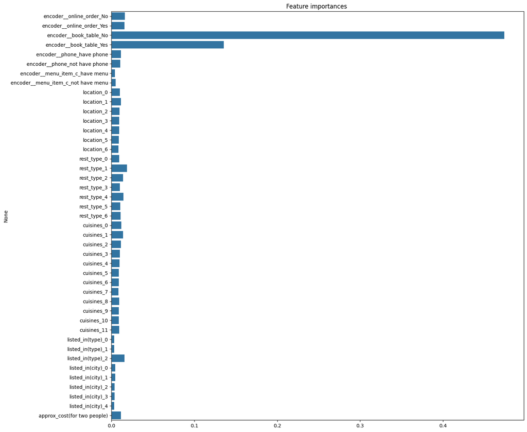

```python
plt.figure(figsize=(15,15))
sns.barplot(x=feature_important,y=df_preprocces.columns)
plt.title("Feature importances ")
plt.show()
```

- Note : **Book Table** is the most important feature in data

**The final accuracy before and after tuning :**

```python
print("Training accuracy of before tuning =",score["train_score"].mean().round(4))
print("Testing accuracy of before tuning =",score["test_score"].mean().round(4))
print("*"*50)
print("Training accuracy of after tuning  =",score3["train_score"].mean().round(4))
print("Testing accuracy of after tuning =",score3["test_score"].mean().round(4))
```

```
Training accuracy of before tuning = 0.8849
Testing accuracy of before tuning = 0.7702
Training accuracy of after tuning  = 0.9901
Testing accuracy of after tuning = 0.8536
```

```python
model=gsearch4.best_estimator_
model
```

```
Pipeline(steps=[('ct',
                 ColumnTransformer(transformers=[('ohe', OneHotEncoder(),
                                                  ['online_order', 'book_table',
                                                   'phone', 'menu_item_c']),
                                                 ('binary', BinaryEncoder(),
                                                  ['location', 'rest_type',
                                                   'cuisines',
                                                   'listed_in(type)',
                                                   'listed_in(city)']),
                                                 ('robust', RobustScaler(),
                                                  ['approx_cost(for two '
                                                   'people)'])])),
                ('XGB',
                 XGBClassifier(base_score=None, booster=None, callbacks=...
                               feature_types=None, gamma=0.0, grow_policy=None,
                               importance_type=None,
                               interaction_constraints=None, learning_rate=0.1,
                               max_bin=None, max_cat_threshold=None,
                               max_cat_to_onehot=None, max_delta_step=None,
                               max_depth=9, max_leaves=None, min_child_weight=1,
                               missing=nan, monotone_constraints=None,
                               multi_strategy=None, n_estimators=1000,
                               n_jobs=None, nthread=4, num_parallel_tree=None, ...))])
```

```python
model.fit(X,y)
```

```
Pipeline(steps=[('ct',
                 ColumnTransformer(transformers=[('ohe', OneHotEncoder(),
                                                  ['online_order', 'book_table',
                                                   'phone', 'menu_item_c']),
                                                 ('binary', BinaryEncoder(),
                                                  ['location', 'rest_type',
                                                   'cuisines',
                                                   'listed_in(type)',
                                                   'listed_in(city)']),
                                                 ('robust', RobustScaler(),
                                                  ['approx_cost(for two '
                                                   'people)'])])),
                ('XGB',
                 XGBClassifier(base_score=None, booster=None, callbacks=...
                               feature_types=None, gamma=0.0, grow_policy=None,
                               importance_type=None,
                               interaction_constraints=None, learning_rate=0.1,
                               max_bin=None, max_cat_threshold=None,
                               max_cat_to_onehot=None, max_delta_step=None,
                               max_depth=9, max_leaves=None, min_child_weight=1,
                               missing=nan, monotone_constraints=None,
                               multi_strategy=None, n_estimators=1000,
                               n_jobs=None, nthread=4, num_parallel_tree=None, ...))])
```

**Save and load Model**

```python
import joblib
joblib.dump(model,"model.pkl")#save model
joblib.dump(X.columns,"input.pkl")#save input columns

model=joblib.load("model.pkl") #load model
```

**Testing model**

```python
# in this sample data rate = 1
data={'online_order': 'Yes',
 'book_table': 'No',
 'phone':'have phone',
 'location':'MG Road',
 'rest_type':'Cafe, Bakery',
 'cuisines':'Cafe, Bakery',
 'approx_cost(for two people)':500.0,
 'menu_item_c':'have menu',
 'listed_in(type)':'Desserts',
 'listed_in(city)':'Church Street'}
df_test=pd.DataFrame(data,index=[0])
df_test
```

|  | online_order | book_table | phone | location | rest_type | cuisines | approx_cost(for two people) | menu_item_c | listed_in(type) | listed_in(city) |
| --- | --- | --- | --- | --- | --- | --- | --- | --- | --- | --- |
| 0 | Yes | No | have phone | MG Road | Cafe, Bakery | Cafe, Bakery | 500.0 | have menu | Desserts | Church Street |

```python
model.predict(df_test)
```

```
array([1])
```

```python
#function predict
def prediction(df):
    value_predict=model.predict(df)[0]
    if value_predict ==1:
        return "This restaurant will be successful"
    else:
        return "This restaurant will be not successful"
```

```python
prediction(df_test)
```

```
'This restaurant will be successful'
```

```python
!pip install nbconvert
```

```python
!jupyter nbconvert --to html /content/Capstone.ipynb
```